# Coral skeletal cores as windows into past Symbiodiniaceae community dynamics

Jose F. Grillo, Vanessa Tirpitz, Jessica Reichert, Marine Canesi, Stéphanie Reynaud, Eric Douville, Maren Ziegler

2025-09-17

# Introduction

This document contains all analyses of the SymPortal Post-MED sequences obtained from coral skeleton core samples collected during the TARA Pacific expedition for the reconstruction of Symbiodiniaceae communities over time.

# General aim

The overarching goal of this study was to evaluate the use of skeleton cores from massive coral species for the reconstruction of Symbiodiniaceae communities at decadal and centennial time scales across species and locations. For this, century-old coral skeleton cores were sampled from two massive species (*Porites lobata* and *Diploastrea heliopora*) from two locations in the Pacific (Papua New Guinea and Palau) and ancient Symbiodiniaceae community dynamics were analyzed using ITS2 amplicon sequencing.

## Specific aims

**Aim 1 - DNA method effects:**

Assess the effect of three different DNA extraction methods on the reconstructed Symbiodiniaceae communities.

**Aim 2 - Species x Location effects:**

Evaluate changes in reconstructed communities obtained by species and sampling location.

**Aim 3 - Dynamics related to past environmental changes:**

Probe differences in the reconstruction dynamics between two massive growing coral species in the context of past potential heat stress events.

# Experimental factors

- **Sampling location:**
  - Palau (sampled in 2017)
  - Papua New Guinea (PNG - sampled in 2018)
- **Species:**
  - *Porites lobata* (1 core for each sampling location, 2 cores total)
  - *Diploastrea heliopora* (1 core for each sampling location, 2 cores total)
- **DNA extraction method:** Only for the PNG Porites cores
  - PowerSoil
  - PowerSoil + EDTA
  - Ancient DNA protocol
- **Chronology:**
  - Decadal scale (Pieces from 0 to 6)
  - Century scale:
    - Porites: Fragments 16, 17 & 18 (equivalent to 80, 85 & 90 year-old fragments)
    - Diploastrea: Fragments 20, 21 & 22 (equivalent to 100, 105 & 110 year-old fragments)

# Load data and packages

All packages that were employed for the analysis and visualization were loaded here

```r
#General data manipulation and visualization
library(tidyverse)
#Multivariate analyses
##Package for performing ordination, PERMANOVA and Betadisper
library(vegan)
##Package for performing pairwise comparisons for PERMANOVA
library(pairwiseAdonis)
```

```r
#Data visualization packages
##Package for performing Upset plot
library(ComplexUpset)
##Package for joining ggplot-based plots
library(patchwork)
##Package to extract plot legends
library(ggpubr)
##Package for creating color palettes
library(ggnested)
```

The datasets were:

- **Metadata:** File containing the metadata of the cores and experimental factors
- **Absolute_abundance:** File containing the Post-MED sequences
- **NOAA_CRW:** File containing the Sea surface temperature (SST) and Number of days with bleaching alerts for Palau and Papua New Guinea along with additional environmental variables.

```r
##Sample Metadata
Metadata <- read.delim(file = "Data/Metadata.txt", header = T, sep = "\t", dec = ".")

##Absolute abundance of Post-MED sequences
Absolute_abundance <- read.delim(file = "Data/Absolute_Abundance.txt", header = T, sep = "\t", dec = ".")

#NOAA CRW data
NOAA_CRW <- read.csv(file = "Data/SST_NOAA_CRW_joined.csv", header = T, sep = ",", dec = ".")
```

# Data preprocessing

The main goal of this section was to prepare the datasets to perform data visualization and statistical testing.

## Create the complete, tidy dataset

The metadata file was modified to include additional relevant variables for downstream analyses including information related to coral genus, fragment age and DNA extraction method.

```r
#Create a clean dataframe
Metadata_clean <- Metadata %>%
  #Select the relevant columns
  select(sample_uid, sample_name, post_med_absolute) %>%
  #Create new Metadata columns
  mutate(

    #Coral genera
    Coral_genus = factor(x = case_when(grepl(pattern = "^P", x = sample_name, ignore.case = T) ~ "Porites",
                           grepl(pattern = "^D", x = sample_name, ignore.case = T) ~ "Diploastrea",
                           grepl(pattern = "^C", x = sample_name, ignore.case = T) ~ "Neg_Control",
                           grepl(pattern = "^G", x = sample_name, ignore.case = T) ~ "PCR_Blank_Seq"), levels = c("Porites", "Diploastrea", "Neg_Control", "PCR_Blank_Seq")),

    #DNA extraction method
    DNA_method = factor(x = case_when(grepl(pattern = "B$", x = sample_name, ignore.case = T) ~ "PowerSoil_EDTA",
                              grepl(pattern = "D$", x = sample_name, ignore.case = T) ~ "PowerSoil",
                              grepl(pattern = "E$", x = sample_name, ignore.case = T) ~ "PowerSoil_EDTA",
                              grepl(pattern = "F$", x = sample_name, ignore.case = T) ~ "Ancient_DNA"), levels = c("PowerSoil", "PowerSoil_EDTA", "Ancient_DNA")),

    #Sampling location
    Location = factor(x = case_when(grepl(pattern = "B$", x = sample_name, ignore.case = T) ~ "Palau",
                              grepl(pattern = "D$", x = sample_name, ignore.case = T) ~ "PNG",
                              grepl(pattern = "E$", x = sample_name, ignore.case = T) ~ "PNG",
                              grepl(pattern = "F$", x = sample_name, ignore.case = T) ~ "PNG"), levels = c("Palau", "PNG")),

    #Number asociated with each fragment
    Fragment_label = factor(x = case_when(grepl(pattern = "^[PD]0", x = sample_name, ignore.case = T) ~ "Head",
                                           grepl(pattern = "^[PD]1[^678]", x = sample_name, ignore.case = T) ~ "1",
                                           grepl(pattern = "^[PD]2[^012]", x = sample_name, ignore.case = T) ~ "2",
                                           grepl(pattern = "^[PD]3", x = sample_name, ignore.case = T) ~ "3",
                                           grepl(pattern = "^[PD]4", x = sample_name, ignore.case = T) ~ "4",
                                           grepl(pattern = "^[PD]5", x = sample_name, ignore.case = T) ~ "5",
                                           grepl(pattern = "^[PD]6", x = sample_name, ignore.case = T) ~ "6",
                                           grepl(pattern = "P16", x = sample_name, ignore.case = T) ~ "Anc1",
                                           grepl(pattern = "P17", x = sample_name, ignore.case = T) ~ "Anc2",
                                           grepl(pattern = "P18", x = sample_name, ignore.case = T) ~ "Anc3",
                                           grepl(pattern = "D20", x = sample_name, ignore.case = T) ~ "Anc1",
                                           grepl(pattern = "D21", x = sample_name, ignore.case = T) ~ "Anc2",
                                           grepl(pattern = "D22", x = sample_name, ignore.case = T) ~ "Anc3"), levels = c("Head", "1", "2", "3", "4", "5", "6", "Anc1", "Anc2", "Anc3")),

         #Age since sampling of each fragment
         Fragment_age = factor(x = case_when(grepl(pattern = "^[PD]0", x = sample_name, ignore.case = T) ~ "0",
                                           grepl(pattern = "^[PD]1[^678]", x = sample_name, ignore.case = T) ~ "5",
                                           grepl(pattern = "^[PD]2[^012]", x = sample_name, ignore.case = T) ~ "10",
                                           grepl(pattern = "^[PD]3", x = sample_name, ignore.case = T) ~ "15",
                                           grepl(pattern = "^[PD]4", x = sample_name, ignore.case = T) ~ "20",
                                           grepl(pattern = "^[PD]5", x = sample_name, ignore.case = T) ~ "25",
                                           grepl(pattern = "^[PD]6", x = sample_name, ignore.case = T) ~ "30",
                                           grepl(pattern = "P16", x = sample_name, ignore.case = T) ~ "80",
                                           grepl(pattern = "P17", x = sample_name, ignore.case = T) ~ "85",
                                           grepl(pattern = "P18", x = sample_name, ignore.case = T) ~ "90",
                                           grepl(pattern = "D20", x = sample_name, ignore.case = T) ~ "100",
                                           grepl(pattern = "D21", x = sample_name, ignore.case = T) ~ "105",
                                           grepl(pattern = "D22", x = sample_name, ignore.case = T) ~ "110"), levels = c("0", "5", "10", "15", "20", "25", "30", "80", "85", "90", "100", "105", "110"))) %>%
  #Rename the relevant columns
  rename(Sample_SymPortal_code = sample_uid, Sample_name = sample_name, Post_MED_sequences = post_med_absolute) %>%
  #Reorder the columns
  select(Sample_SymPortal_code, Sample_name, Fragment_label, Fragment_age, Location, Coral_genus, DNA_method, Post_MED_sequences)
```

To obtain a final dataset where the metadata and post-MED sequence abundance is present, the expanded metadata and absolute abundance datasets were joined.

```r
#Creating the long-format joined dataset
Abs_abund <- left_join(Metadata_clean,
                             Absolute_abundance %>%
                               #Modify sample code variable name
                               rename(Sample_SymPortal_code = sample_uid),
                             by = "Sample_SymPortal_code") %>%
  #Change the data structure to long format
  pivot_longer(cols = -c("Sample_SymPortal_code", "Sample_name", "Fragment_label", "Fragment_age", "Location", "Coral_genus", "DNA_method", "Post_MED_sequences"), names_to = "Symbiont_genus", values_to = "Abundance") %>%
  #Create a new variable with the simplified Clades
  mutate(Symbiont_genus_simp = case_when(grepl(pattern = "^A|_A$", x = Symbiont_genus) ~ "A",
                                grepl(pattern = "^B|_B$", x = Symbiont_genus) ~ "B",
                                grepl(pattern = "^C|_C$", x = Symbiont_genus) ~ "C",
                                grepl(pattern = "^D|_D$", x = Symbiont_genus) ~ "D",
                                TRUE ~ Symbiont_genus), .before = "Symbiont_genus") %>%
  #Remove the SymPortal sample code
  select(-Sample_SymPortal_code)
```

The final step was verifying that all the information is present from both datasets

```r
#Verifiying that the information matches
all((Abs_abund %>%
  #Group the data by sample
  group_by(Sample_name, Post_MED_sequences) %>%
  #Obtain the total number of sequences by each Genus DIV
  summarize(Total_Abundance = sum(Abundance)))$Post_MED_sequences ==
  (Abs_abund %>%
  #Group the data by sample
  group_by(Sample_name, Post_MED_sequences) %>%
  #Obtain the total number of sequences by each Genus DIV
  summarize(Total_Abundance = sum(Abundance)))$Total_Abundance)
```

```
## [1] TRUE
```

### Filter out blanks and negative controls

All post-MED sequences present in the processing blanks and negative controls were filtered out from the entire dataset.

Example:

[output not shown]

```r
Blanks <- Abs_abund %>%
  #Filter to only obtain Blanks and the PCR names
  filter(grepl(pattern = "^C_|G_PCR", x = Sample_name)) %>%
  #Pre-filter to obtain abundances higher than 0
  filter(Abundance > 0)


G_PCR <- Blanks %>%
  #Filter the dataset to obtain only the desired sample
  filter(Sample_name == "G_PCR") %>%
  #Select the variables
  select(Symbiont_genus)


C_P_B <- Blanks %>%
  #Filter the dataset to obtain only the desired sample
  filter(Sample_name == "C_P_B") %>%
  #Select the variables
  select(Symbiont_genus) %>%
  #Include the PCR blanks
  left_join(G_PCR, by = "Symbiont_genus", keep = T) %>%
  #Rename the Symbiont_genus columns
  rename(Symbiont_genus = Symbiont_genus.x, PCR_Blank = Symbiont_genus.y)


C_P_D <- Blanks %>%
  #Filter the dataset to obtain only the desired sample
  filter(Sample_name == "C_P_D") %>%
  #Obtain the names of the Symbiont_genuss per blanks
  distinct(Symbiont_genus) %>%
  #Include the PCR blanks
  left_join(G_PCR, by = "Symbiont_genus", keep = T) %>%
  #Rename the Symbiont_genus columns
  rename(Symbiont_genus = Symbiont_genus.x, PCR_Blank = Symbiont_genus.y)


C_P_E <- Blanks %>%
  #Filter the dataset to obtain only the desired sample
  filter(Sample_name == "C_P_E") %>%
  #Obtain the names of the Symbiont_genuss per blanks
  distinct(Symbiont_genus) %>%
  #Include the PCR blanks
  left_join(G_PCR, by = "Symbiont_genus", keep = T) %>%
  #Rename the Symbiont_genus columns
  rename(Symbiont_genus = Symbiont_genus.x, PCR_Blank = Symbiont_genus.y)


C_P_F <- Blanks %>%
  #Filter the dataset to obtain only the desired sample
  filter(Sample_name == "C_P_F") %>%
  #Obtain the names of the Symbiont_genuss per blanks
  distinct(Symbiont_genus) %>%
  #Include the PCR blanks
  left_join(G_PCR, by = "Symbiont_genus", keep = T) %>%
  #Rename the Symbiont_genus columns
  rename(Symbiont_genus = Symbiont_genus.x, PCR_Blank = Symbiont_genus.y)


C_D_B <- Blanks %>%
  #Filter the dataset to obtain only the desired sample
  filter(Sample_name == "C_D_B") %>%
  #Obtain the names of the Symbiont_genuss per blanks
  distinct(Symbiont_genus) %>%
  #Include the PCR blanks
  left_join(G_PCR, by = "Symbiont_genus", keep = T) %>%
  #Rename the Symbiont_genus columns
  rename(Symbiont_genus = Symbiont_genus.x, PCR_Blank = Symbiont_genus.y)


C_D_E <- Blanks %>%
  #Filter the dataset to obtain only the desired sample
  filter(Sample_name == "C_D_E") %>%
  #Obtain the names of the Symbiont_genuss per blanks
  distinct(Symbiont_genus) %>%
  #Include the PCR blanks
  left_join(G_PCR, by = "Symbiont_genus", keep = T) %>%
  #Rename the Symbiont_genus columns
  rename(Symbiont_genus = Symbiont_genus.x, PCR_Blank = Symbiont_genus.y)


#________________________________________________________________________

PXB_adj <- Abs_abund %>%
  #Filter the samples to obtain the desired sample
  filter(grepl(pattern = "P\\dB|P\\d\\dB", x = Sample_name)) %>%
  #Join with the corresponding blank
  left_join(C_P_B, by = "Symbiont_genus", keep = T) %>%
  #Filter out the rows with NAs as determined by the Blank
  filter(is.na(Symbiont_genus.y)) %>%
  #Rename the Symbiont_genus columns
  rename(Symbiont_genus = Symbiont_genus.x, Blank = Symbiont_genus.y) #%>%
  #Filter out the Symbiont_genuss with abundance of 0
  #filter(Abundance > 0)


PXD_adj <- Abs_abund %>%
  #Filter the samples to obtain the desired sample
  filter(grepl(pattern = "P\\dD|P\\d\\dD", x = Sample_name)) %>%
  #Join with the corresponding blank
  left_join(C_P_D, by = "Symbiont_genus", keep = T) %>%
  #Filter out the rows with NAs as determined by the Blank
  filter(is.na(Symbiont_genus.y)) %>%
  #Rename the Symbiont_genus columns
  rename(Symbiont_genus = Symbiont_genus.x, Blank = Symbiont_genus.y) #%>%
  #Filter out the Symbiont_genuss with abundance of 0
  #filter(Abundance > 0)


PXE_adj <- Abs_abund %>%
  #Filter the samples to obtain the desired sample
  filter(grepl(pattern = "P\\dE|P\\d\\dE", x = Sample_name)) %>%
  #Join with the corresponding blank
  left_join(C_P_E, by = "Symbiont_genus", keep = T) %>%
  #Filter out the rows with NAs as determined by the Blank
  filter(is.na(Symbiont_genus.y)) %>%
  #Rename the Symbiont_genus columns
  rename(Symbiont_genus = Symbiont_genus.x, Blank = Symbiont_genus.y)  #%>%
  #Filter out the Symbiont_genuss with abundance of 0
  #filter(Abundance > 0)


PXF_adj <- Abs_abund %>%
  #Filter the samples to obtain the desired sample
  filter(grepl(pattern = "P\\dF|P\\d\\dF", x = Sample_name)) %>%
  #Join with the corresponding blank
  left_join(C_P_F, by = "Symbiont_genus", keep = T) %>%
  #Filter out the rows with NAs as determined by the Blank
  filter(is.na(Symbiont_genus.y)) %>%
  #Rename the Symbiont_genus columns
  rename(Symbiont_genus = Symbiont_genus.x, Blank = Symbiont_genus.y) #%>%
  #Filter out the Symbiont_genuss with abundance of 0
  #filter(Abundance > 0)


DXB_adj <- Abs_abund %>%
  #Filter the samples to obtain the desired sample
  filter(grepl(pattern = "D\\dB|D\\d\\dB", x = Sample_name)) %>%
  #Join with the corresponding blank
  left_join(C_D_B, by = "Symbiont_genus", keep = T) %>%
  #Filter out the rows with NAs as determined by the Blank
  filter(is.na(Symbiont_genus.y)) %>%
  #Rename the Symbiont_genus columns
  rename(Symbiont_genus = Symbiont_genus.x, Blank = Symbiont_genus.y) #%>%
  #Filter out the Symbiont_genuss with abundance of 0
  #filter(Abundance > 0)


DXE_adj <- Abs_abund %>%
  #Filter the samples to obtain the desired sample
  filter(grepl(pattern = "D\\dE|D\\d\\dE", x = Sample_name)) %>%
  #Join with the corresponding blank
  left_join(C_D_E, by = "Symbiont_genus", keep = T) %>%
  #Filter out the rows with NAs as determined by the Blank
  filter(is.na(Symbiont_genus.y)) %>%
  #Rename the Symbiont_genus columns
  rename(Symbiont_genus = Symbiont_genus.x, Blank = Symbiont_genus.y) #%>%
  #Filter out the Symbiont_genuss with abundance of 0
  #filter(Abundance > 0)

#Join all the separate datasets
Abs_abund_clean <- bind_rows(PXB_adj, DXB_adj, PXD_adj, PXE_adj, PXF_adj, DXE_adj) %>%
  #Select the relevant variables
  select(-c("Blank", "PCR_Blank")) %>%
  #Include the sample names as a factor
  mutate(Sample_name = factor(x = Sample_name, levels = c("P0B", "P1B", "P2B", "P3B", "P4B", "P5B", "P6B", "P16B", "P17B", "P18B",
                                                               "P0D", "P1D", "P2D", "P3D", "P4D", "P5D", "P6D", "P16D", "P17D", "P18D",
                                                               "P0E", "P1E", "P2E", "P3E", "P4E", "P5E", "P6E", "P16E", "P17E", "P18E",
                                                               "P0F", "P1F", "P2F", "P3F", "P4F", "P5F", "P6F", "P16F", "P17F", "P18F",
                                                               "D0B", "D1B", "D2B", "D3B", "D4B", "D5B", "D6B", "D20B", "D21B", "D22B",
                                                               "D0E", "D1E", "D2E", "D3E", "D4E", "D5E", "D6E", "D20E", "D21E", "D22E")), .before = Fragment_label)

#Remove temporary datasets
rm(Blanks, C_D_B, C_D_E, C_P_B, C_P_D, C_P_E, C_P_F, DXB_adj, DXE_adj, G_PCR, PXB_adj, PXD_adj, PXE_adj, PXF_adj)
```

Finally we updated the dataset to include the total count of Post-MED sequences after the blank correction

```r
#Join both datasets
Abs_abund_clean <- left_join(
  Abs_abund_clean,

  #Percentage of lost sequences per sample
  Abs_abund_clean %>%
  #Group the data by sample
  group_by(Sample_name, Fragment_label, Fragment_age, Location, Coral_genus, DNA_method, Post_MED_sequences) %>%
  #Obtain the total number of sequences per sample
  summarize(Post_MED_sequences_blank_corrected = sum(Abundance)) %>%
  #Ungroup the data
  ungroup() %>%
  #Create a new variable with the difference
  mutate(Lost_seqs_blank_correction = Post_MED_sequences - Post_MED_sequences_blank_corrected,
         Lost_seqs_blank_correction_perc = (Post_MED_sequences_blank_corrected/Post_MED_sequences) * 100),
  by = colnames(Abs_abund_clean)[1:7]) %>%
  #Sort the columns
  select(Sample_name, Fragment_label, Fragment_age, Location, Coral_genus, DNA_method, Post_MED_sequences, Post_MED_sequences_blank_corrected, Lost_seqs_blank_correction, Lost_seqs_blank_correction_perc, Symbiont_genus_simp, Symbiont_genus, Abundance)
```

```
## 'Fragment_age', 'Location', 'Coral_genus', 'DNA_method'. You can override using
```

## Calculate relative abundance over 0.1%

We proceeded to calculate the relative abundance of the samples. For this we employed the Post-MED sequences after blank correction

```r
Abund_clean_rel_0.1 <- Abs_abund_clean %>%
  #Calculate the relative abundance
  mutate(Rel_abund = Abundance/Post_MED_sequences_blank_corrected,
         Rel_abund_per = (Abundance/Post_MED_sequences_blank_corrected) * 100,
         .after = Abundance) %>%
  #Assign the sequences below 0.1% to a "Others" category
  mutate(
    #Create a new Symbiont_genus variable that contains the Others category
    Symbiont_genus_others = case_when(Rel_abund_per < 0.1 ~ "Others",
                               TRUE ~ Symbiont_genus),
    #Create a new Symbiont_genus_simp variable that includes the Others category
    Symbiont_genus_simp_others = case_when(Symbiont_genus_others == "Others" ~ "Others",
                                    TRUE ~ Symbiont_genus_simp) )
```

## Assign colors to each Genus DIV

We proceeded to pre-assign a defined color to each DIV present in the **blank-corrected** dataset as it represents the most complete data that we will employ. By assign a color to each post-MED sequence (DIV) we can ensure a uniform color distribution in all analyses (for example all bar plots).

In order to assign the colors for each main symbiont genus, we employed the package **ggnested**, which allows us to assign a main color palette for each symbiont genus and it can automatically assign a gradient for all the DIVs present in a genus.

For further references for the color palette check: https://github.com/gmteunisse/ggnested

- **Symbiodinium**: “#F0E442”
- **Breviolum**: “#0072B2”
- **Cladocopium**: “#CC79A7”
- **Durusdinium**: “#202A2”
- **Others** color: “#bbbbbb”

```r
#Extract the color codes
Color_palette_Symbiont_genus <- ggnested::extract_palette(Abs_abund_clean %>% ggnested::ggnested(aes(x = Sample_name, y = Abundance, main_group = Symbiont_genus_simp, sub_group = Symbiont_genus), main_palette = c("#F0E442", "#0072B2", "#CC79A7", "#202A25"), gradient_type = "fancy", min_l = 0.25, max_l = 0.95) + geom_col( show.legend = F) ) %>%
  #Obtain unique columns for Symbiont_genus and Symbiont_genus_simp
  separate(col = group_subgroup, into = c("Symbiont_genus_simp", "Symbiont_genus"), sep = " - ", remove = F) %>%
  #Rename variables
  rename(Symbiont_genus_combined = group_subgroup, Symbiont_genus_simp_color = group_colour, Symbiont_genus_color = subgroup_colour)
```

Once the colors were assigned and we verified that there was enough contrast between them with a bar plot containing all samples and Genus DIV

```r
#Join both datasets
Abs_abund_clean <- left_join(Abund_clean_rel_0.1,
                  Color_palette_Symbiont_genus,
                  by = c("Symbiont_genus", "Symbiont_genus_simp")) %>%
  #Create a new Clade variable for a better legend
  mutate(Symbiont_genus_combined = str_replace(string = Symbiont_genus_combined, pattern = " - ", replacement = ": "),
         #Create a new Symbiont_genus_color variable that assigns grey for the Others category
    Symbiont_genus_color_others = case_when(Symbiont_genus_others == "Others" ~ "#bbbbbb",
                                     TRUE ~ Symbiont_genus_color),

    #Create a new Symbiont_genus_color variable that assigns grey for the Others category
    Symbiont_genus_simp_color_others = case_when(Symbiont_genus_simp_others == "Others" ~ "#bbbbbb",
                                     TRUE ~ Symbiont_genus_simp_color),
    #Create a new Symbiont_genus_combined that includes the Other category
    Symbiont_genus_combined_others = case_when(Symbiont_genus_simp_others  == "Others" ~ "Others",
                                        TRUE ~ Symbiont_genus_combined) )
```

## Obtain a final working dataset

The final step was to clean up the variables inside the final dataset to only include relevant variables for downstream analyses

```r
#Create the new dataset
Abundance <- Abs_abund_clean %>%
  #Select the relevant variables and reorder them
  select("Sample_name", "Fragment_label", "Fragment_age", "Location", "Coral_genus", "DNA_method", "Symbiont_genus_simp", "Symbiont_genus_simp_others", "Symbiont_genus", "Symbiont_genus_others", "Abundance", "Rel_abund", "Rel_abund_per", "Symbiont_genus_simp_color", "Symbiont_genus_color", "Symbiont_genus_color_others", "Symbiont_genus_simp_color_others", "Symbiont_genus_combined", "Symbiont_genus_combined_others")

#_______________

#Remove the unused datasets
rm(Abs_abund, Abs_abund_clean, Absolute_abundance, Metadata, Metadata_clean, Abund_clean_rel_0.1, Color_palette_Symbiont_genus)
```

## Variable explanation

All the modifications done to obtain a final dataset where the metadata and absolute abundance of the Post-MED sequences culminated in the dataset: **Abundance**.

The variables present in the dataset are:

- **Sample_name:** The name of each fragment created as a code that combines the coral genus (P = Porites, D = Diploastrea), fragment label (See variable **Fragment_label**) and sampling location and DNA extraction method (B = Palau & PowerSoil EDTA, D = Papua New Guinea & PowerSoil, E = Papua New Guinea & PowerSoil EDTA, F = Papua New Guinea & Ancient DNA).
- **Fragment_label:** Number given to each fragment to represent the age of the fragment. The fragments labelled from 0 - 6 were present for all samples. Fragments labelled as 16 - 18 were only present for *Porites lobata*. Fragments labelled as 20 - 22 were only present for *Diploastrea heliopora*. (0 = Head, 1 = 5-year-old fragment, 2 = 10-year-old fragment, 3 = 15-year-old fragment, 4 = 20-year-old fragment, 5 = 25-year-old fragment, 6 = 30-year-old fragment, 16 = 80-year-old fragment, 17 = 85-year-old fragment, 18 = 90-year-old fragment, 20 = 100-year-old fragment, 21 = 105-year-old fragment, 22 = 110-year-old fragment).
- **Fragment_age:** Age of each fragment. (See **Fragment_label**)
- **Location:** Sampling location of each core. Palau and Papua New Guinea (PNG)
- **Coral_genus:** Genus of the coral skeleton. (Porites = *Porites lobata*, Diplo = *Diploastrea heliopora*)
- **DNA_method:** Method employed for DNA extraction. (Qiagen PowerSoil Pro kit = PowerSoil, Decalcification and Qiagen PowerSoil Pro kit = PowerSoil_EDTA, Decalcification and Ancient DNA extraction protocol = Ancient_DNA)
- **Symbiont_genus_simp:** Simplified classification by Clade of each Post-MED sequences. Grouped by Symbiodiniaceae genus/clade (See *Symbiont_genus*)
- **Symbiont_genus_simp_others:** Simplified classification by “Clade” of each Post-MED sequences. Grouped by Symbiodiniaceae genus/clade. The others category was added for those sequences with a relative abundance lower than 0.1% over all samples.
- **Symbiont_genus:** Post-MED sequences corresponding to the genus of each Symbiodiniaceae as assigned by SymPortal (following the old Clade classification). For simplicity in the analysis the genera were kept as clades during the analysis. (Clade A = *Symbiodinium*, Clade B = *Breviolum*, Clade C = *Cladocopium*, Clade D = *Durusdinium*)
- **Symbiont_genus_others:** Post-MED sequences corresponding to the genus of each Symbiodiniaceae as assigned by SymPortal (following the old Clade classification). For simplicity in the analysis the genera were kept as clades during the analysis. (Clade A = *Symbiodinium*, Clade B = *Breviolum*, Clade C = *Cladocopium*, Clade D = *Durusdinium*). The others category was added for those sequences with a relative abundance lower than 0.1% over all samples.
- **Abundance:** Absolute abundance of the Post-MED sequences of each Symbiodiniaceae genus/clade
- **Rel_abund:** Relative abundance of the Post-MED sequences of each Symbiodiniaceae genus/clade per sample
- **Rel_abund_per:** Percentage relative abundance of the Post-MED sequences of each Symbiodiniaceae genus/clade per sample
- **Symbiont_genus_simp_color:** Colors assigned to each Post-MED sequence grouped by **Symbiont_genus_simp**
- **Symbiont_genus_color:** Colors assigned to each Post-MED sequence grouped by **Symbiont_genus**
- **Symbiont_genus_color_others:** Colors assigned to each Post-MED sequence grouped by **Symbiont_genus_others**. The others category was assigned to a gray color.
- **Symbiont_genus_simp_color_others:** Colors assigned to each Post-MED sequence grouped by **Symbiont_genus_simp_others**. The others category was assigned to a gray color.
- **Symbiont_genus_combined:** Category created for easier plotting.
- **Symbiont_genus_combined_others:** Category created for easier plotting including others category.

# Data analysis

## Aim 1 - DNA method effects

**Assess the effect of three different DNA extraction methods on the reconstructed Symbiodiniaceae communities.**

In order to answer these questions we proceeded to visualize the Genus (DIV) as bar plots, NMDS plots and we evaluated the shared Genus (DIV) between the DNA extraction methods.

### Bar plots

We visualized relative abundance of the post-MED sequences through a stacked bar plot.

> NOTE: The relative abundance *under* 0.1% was included as the “Others” category

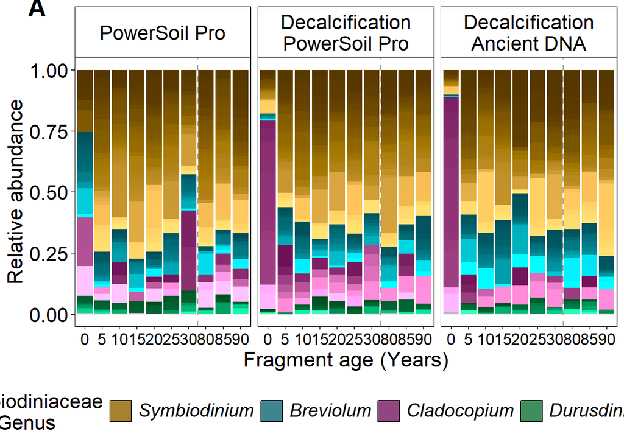

```r
DNA_method_bar_plot <- Abundance %>%
  #Select the PNG Porites samples
  filter(Location == "PNG" & Coral_genus == "Porites") %>%
  #Create a new DNA_method variable for plotting
  mutate(DNA_method_plot = factor(x = DNA_method, levels = c("PowerSoil", "PowerSoil_EDTA", "Ancient_DNA"), labels = c("PowerSoil Pro", "Decalcification\nPowerSoil Pro", "Decalcification\nAncient DNA")) ) %>%
  #Select the data for the plot
  ggplot() +
  # First geom_col for the fill aesthetic (stacked bars)
  geom_col(aes(x = Fragment_age, y = Rel_abund,
               fill = Symbiont_genus_combined_others),
           color = NA, show.legend = FALSE) +  # Hide color here to prevent duplication

  # Second geom_col for the color aesthetic (transparent borders)
  geom_col(data = Abundance %>%
  #Select the PNG Porites samples
  filter(Location == "PNG" & Coral_genus == "Porites") %>%
  #Create a new DNA_method variable for plotting
  mutate(DNA_method_plot = factor(x = DNA_method, levels = c("PowerSoil", "PowerSoil_EDTA", "Ancient_DNA"), labels = c("PowerSoil Pro", "Decalcification\nPowerSoil Pro", "Decalcification\nAncient DNA")),

         Symbiont_genus_simp_others_plot = factor(x = case_when(Symbiont_genus_simp_others == "A" ~ "*Symbiodinium*",
                                                       Symbiont_genus_simp_others == "B" ~ "*Breviolum*",
                                                       Symbiont_genus_simp_others == "C" ~ "*Cladocopium*",
                                                       Symbiont_genus_simp_others == "D" ~ "*Durusdinium*",
                                                       Symbiont_genus_simp_others == "Others" ~ "Others"), levels = c("*Symbiodinium*", "*Breviolum*", "*Cladocopium*", "*Durusdinium*", "Others")) ) ,
           aes(x = Fragment_age, y = Rel_abund,
               color = Symbiont_genus_simp_others_plot),
           fill = NA, alpha = 0, show.legend = TRUE) +
  #Include the scale_manual
  scale_fill_manual(values = setNames(subset(x = Abundance, subset = Location == "PNG" & Coral_genus == "Porites")$Symbiont_genus_color_others, subset(x = Abundance, subset = Location == "PNG" & Coral_genus == "Porites")$Symbiont_genus_combined_others)) +
  #Include the colors
  scale_color_manual(values = c("transparent", "transparent", "transparent", "transparent", "transparent"),  name = "Symbiodiniaceae\nGenus") +
  #Change the legend
  guides(fill = "none",
          color = guide_legend(override.aes = list(
    fill = c("#a5822d", "#3d8590", "#91467f", "#408e5e", "#bbbbbb"),
    color = c("#a5822d", "#3d8590", "#91467f", "#408e5e", "#bbbbbb"),
    alpha = 1)) )  +

  #Include facets
  facet_grid(cols = vars(DNA_method_plot),  scales = "free") +
  #Include a vertical line to indicate the ancient samples
  geom_vline(xintercept = 7.5, linetype = "dashed", linewidth = 0.7, color = "darkgray") +
  #Include plot title
  labs(x = "Fragment age (Years)", y = "Relative abundance", tag = "A") +
  #Modify the theme
  theme(
    #Eliminate panel grids
    panel.grid = element_blank(),
    #Change background color
    panel.background = element_rect(fill = "white", color = "black"),
    #Increase axes label text size
    axis.text.x = element_text(color = "black", size = 13), #Before size = 10
    axis.text.y = element_text(color = "black", size = 16), #Before size = 12
    axis.title = element_text(color = "black", size = 17), #Before size = 13
    #Change the color of the facet label
    strip.background = element_rect(fill = "white", color = "black"),
    #Increase facet label text size
    strip.text = element_text(color = "black", size = 16), #Before size = 12
    #Change the legend
    legend.title = element_text(color = "black", size = 16, hjust = 0.5), #Before size = 12
    legend.text = ggtext::element_markdown(color = "black", size = 15), #Before size = 12
    legend.position = "bottom",
    #Include tags
    plot.tag = element_text(face = "bold", size = 20),
    plot.tag.position = c(0.05, 1)
#    plot.tag.location = "plot"
    )

DNA_method_bar_plot
```

```r
#ggsave(filename = "DNA_method_bar_plot.png", width = 200, height = 150, units = "mm", dpi = 1800)
#ggsave(filename = "DNA_method_bar_plot.svg", width = 200, height = 150, units = "mm", dpi = 1800)
```

### NMDS plot

To visualize the community structure we performed a NMDS based on Bray-Curtis distance. The ordination was calculated with the logarithm (+1) of the abundances.

> NOTE: We filtered the relative abundance under 0.1%

```r
#Create the datasets

#Ordination
##Set the random seed
set.seed(15081998)
DNA_method_ord <- metaMDS(comm = Abundance %>% filter(Location == "PNG" & Coral_genus == "Porites" & Rel_abund_per > 0.1) %>% mutate(Abundance_log = log(Abundance + 1), .after = Sample_name) %>% pivot_wider(id_cols = Sample_name, names_from = Symbiont_genus, values_from = Abundance_log, values_fill = 0) %>% column_to_rownames(var = "Sample_name"), dist = "bray", k = 3)
```

```
## *** Best solution repeated 1 times
```

```r
#Extract the data
DNA_method_ord_data <- as.data.frame(scores(DNA_method_ord)$sites) %>%
  #Include the metadata

  #Include sample names
  rownames_to_column(var = "Sample_name") %>%
  #Include the Location, Species and DNA_Method
  mutate(Coral_genus = factor(case_when(grepl(pattern = "^P", x = Sample_name, ignore.case = T) ~ "Porites",
                           grepl(pattern = "^D", x = Sample_name, ignore.case = T) ~ "Diploastrea"), levels = c("Porites", "Diploastrea")),

         DNA_method = factor(x = case_when(grepl(pattern = "B$", x = Sample_name, ignore.case = T) ~ "PowerSoil_EDTA",
                                grepl(pattern = "D$", x = Sample_name, ignore.case = T) ~ "PowerSoil",
                                grepl(pattern = "E$", x = Sample_name, ignore.case = T) ~ "PowerSoil_EDTA",
                                grepl(pattern = "F$", x = Sample_name, ignore.case = T) ~ "Ancient_DNA"), levels = c("PowerSoil", "PowerSoil_EDTA", "Ancient_DNA")),

         Location = factor(x = case_when(grepl(pattern = "B$", x = Sample_name, ignore.case = T) ~ "Palau",
                              grepl(pattern = "D$", x = Sample_name, ignore.case = T) ~ "PNG",
                              grepl(pattern = "E$", x = Sample_name, ignore.case = T) ~ "PNG",
                              grepl(pattern = "F$", x = Sample_name, ignore.case = T) ~ "PNG"), levels = c("Palau", "PNG")),

          Fragment_label = factor(x = case_when(grepl(pattern = "^[PD]0", x = Sample_name, ignore.case = T) ~ "Head",
                                           grepl(pattern = "^[PD]1[^678]", x = Sample_name, ignore.case = T) ~ "1",
                                           grepl(pattern = "^[PD]2[^012]", x = Sample_name, ignore.case = T) ~ "2",
                                           grepl(pattern = "^[PD]3", x = Sample_name, ignore.case = T) ~ "3",
                                           grepl(pattern = "^[PD]4", x = Sample_name, ignore.case = T) ~ "4",
                                           grepl(pattern = "^[PD]5", x = Sample_name, ignore.case = T) ~ "5",
                                           grepl(pattern = "^[PD]6", x = Sample_name, ignore.case = T) ~ "6",
                                           grepl(pattern = "P16", x = Sample_name, ignore.case = T) ~ "Anc1",
                                           grepl(pattern = "P17", x = Sample_name, ignore.case = T) ~ "Anc2",
                                           grepl(pattern = "P18", x = Sample_name, ignore.case = T) ~ "Anc3",
                                           grepl(pattern = "D20", x = Sample_name, ignore.case = T) ~ "Anc1",
                                           grepl(pattern = "D21", x = Sample_name, ignore.case = T) ~ "Anc2",
                                           grepl(pattern = "D22", x = Sample_name, ignore.case = T) ~ "Anc3"), levels = c("Head", "1", "2", "3", "4", "5", "6", "Anc1", "Anc2", "Anc3")),

         #Fragment age
         Fragment_age = factor(x = case_when(grepl(pattern = "^[PD]0", x = Sample_name, ignore.case = T) ~ "0",
                                           grepl(pattern = "^[PD]1[^678]", x = Sample_name, ignore.case = T) ~ "5",
                                           grepl(pattern = "^[PD]2[^012]", x = Sample_name, ignore.case = T) ~ "10",
                                           grepl(pattern = "^[PD]3", x = Sample_name, ignore.case = T) ~ "15",
                                           grepl(pattern = "^[PD]4", x = Sample_name, ignore.case = T) ~ "20",
                                           grepl(pattern = "^[PD]5", x = Sample_name, ignore.case = T) ~ "25",
                                           grepl(pattern = "^[PD]6", x = Sample_name, ignore.case = T) ~ "30",
                                           grepl(pattern = "P16", x = Sample_name, ignore.case = T) ~ "80",
                                           grepl(pattern = "P17", x = Sample_name, ignore.case = T) ~ "85",
                                           grepl(pattern = "P18", x = Sample_name, ignore.case = T) ~ "90"), levels = c("0", "5", "10", "15", "20", "25", "30", "80", "85", "90")) )


#_____________________________________________________________________________________________

#Create the color palette

ggnested::extract_palette(DNA_method_ord_data %>%
  #Select the data
  ggnested::ggnested(aes(x = NMDS1, y = NMDS2,
             main_group = Coral_genus,
             sub_group = Fragment_age),
             main_palette = c("#0077b6"),
           gradient_type = "tints") +
  #Select the type of plot
  geom_point(aes(shape = DNA_method), size = 6, show.legend = F) +
  #Change the theme
  theme(panel.grid = element_blank(),
        panel.background = element_rect(fill = "white",  color = "black"),
        legend.position = "bottom") )
```

```
##    group_subgroup group_colour subgroup_colour
## 1     Porites - 0      #0077b6         #008AD3
## 4     Porites - 5      #0077b6         #1895D7
## 7    Porites - 10      #0077b6         #30A0DC
## 10   Porites - 15      #0077b6         #48ACE1
## 13   Porites - 20      #0077b6         #60B7E6
## 16   Porites - 25      #0077b6         #78C3EB
## 19   Porites - 30      #0077b6         #90CEF0
## 22   Porites - 80      #0077b6         #A7DAF5
## 25   Porites - 85      #0077b6         #C0E5FA
## 28   Porites - 90      #0077b6         #D8F1FF
```

```r
#Create the color dataset
DNA_method_ord_colors <- DNA_method_ord_data %>%
  #Include a new variable for the plot
  mutate(Fragment_age_color = case_when(Fragment_age == "0" ~ "white",
                                        Fragment_age == "5" ~ "#C0E5FA",
                                        Fragment_age == "10" ~ "#A7DAF5",
                                        Fragment_age == "15" ~ "#90CEF0",
                                        Fragment_age == "20" ~ "#78C3EB",
                                        Fragment_age == "25" ~ "#60B7E6",
                                        Fragment_age == "30" ~ "#48ACE1",
                                        Fragment_age == "80" ~ "#30A0DC",
                                        Fragment_age == "85" ~ "#1895D7",
                                        Fragment_age == "90" ~ "#008AD3"))
```

```r
#NMDS 1 + 2

DNA_method_ord_plot_1_2 <- DNA_method_ord_data %>%
  #Include a new variable for the plot
  mutate(Fragment_age_color = case_when(Fragment_age == "0" ~ "white",
                                        Fragment_age == "5" ~ "#C0E5FA",
                                        Fragment_age == "10" ~ "#A7DAF5",
                                        Fragment_age == "15" ~ "#90CEF0",
                                        Fragment_age == "20" ~ "#78C3EB",
                                        Fragment_age == "25" ~ "#60B7E6",
                                        Fragment_age == "30" ~ "#48ACE1",
                                        Fragment_age == "80" ~ "#30A0DC",
                                        Fragment_age == "85" ~ "#1895D7",
                                        Fragment_age == "90" ~ "#008AD3")) %>%
  #Select the data for plottiing
  ggplot(aes(x = NMDS1, y = NMDS2)) +
  #Select the type of plot
  geom_point(aes(shape = DNA_method, fill = Fragment_age), size = 10, show.legend = T, color = "#0077b6", stroke = 1.5) +
  #Select the shapes
  scale_shape_manual(values = c(21, 22, 24), name = "DNA extraction\nmethod", labels = c("PowerSoil Pro", "Decalcification\nPowerSoil Pro", "Decalcification\nAncient DNA")) +
  #Include the Stress inside the plot
  annotate(geom = "text", x = -0.3, y = 0.83, label = paste("3D-Stress:", signif(DNA_method_ord$stress, 3)), size = 6) +
  #Include the color selection
  scale_fill_manual(values = setNames(left_join(DNA_method_ord_data, DNA_method_ord_colors)$Fragment_age_color, left_join(DNA_method_ord_data, DNA_method_ord_colors)$Fragment_age),
                    name = "Fragment age",
                    guide = guide_legend(theme = theme(
      legend.direction = "horizontal",
      legend.title.position = "left",
      legend.text = element_text(hjust = 0.5, vjust = 1))) ) +
  #Include the elipses
  stat_ellipse(aes(color = DNA_method), linetype = "dashed", show.legend = F) +
  #Include colors
  scale_color_manual(values = c("#0077b6", "#0077b6", "#0077b6"))+
  #Choose which legends appear
  guides(color = "none",
         shape = "none",
         fill = guide_legend(
           nrow = 1,
           override.aes = list(
           shape = 21,
           color = "#0077b6",
           fill = c("0" ="white", "5" = "#C0E5FA", "10" = "#A7DAF5", "15" = "#90CEF0", "20" = "#78C3EB", "25" = "#60B7E6", "30" = "#48ACE1", "80" = "#30A0DC", "85" = "#1895D7", "90" = "#008AD3")),
           theme = theme(legend.text.position = "bottom",
                         legend.background = element_rect(fill = "transparent"))) ) +
  #Include the stress value
#  labs(subtitle = paste("3D-Stress:", signif(DNA_method_ord$stress, 3))) +
  #Change the theme
  theme(panel.grid = element_blank(),
        panel.background = element_rect(fill = "white",  color = "black"),
        #Modify the caption size
        plot.subtitle = element_text(size = 16),
        #Modify the axis text
        axis.text = element_text(size = 16, color = "black"),
        axis.title = element_text(size = 16),
        #Modify the legend elements
        legend.position = "bottom",
        legend.key = element_rect(fill = "white", color = "white"),
        legend.title = element_text(color = "black", size = 16, hjust = 0.5), #Before size = 12
        legend.text = element_text(color = "black", size = 16), #Before size = 12
        #Include tags
        #plot.tag = element_text(face = "bold", size = 16),
        #plot.tag.location = "plot"
        )
```

```
## DNA_method, Location, Fragment_label, Fragment_age)`
## DNA_method, Location, Fragment_label, Fragment_age)`
```

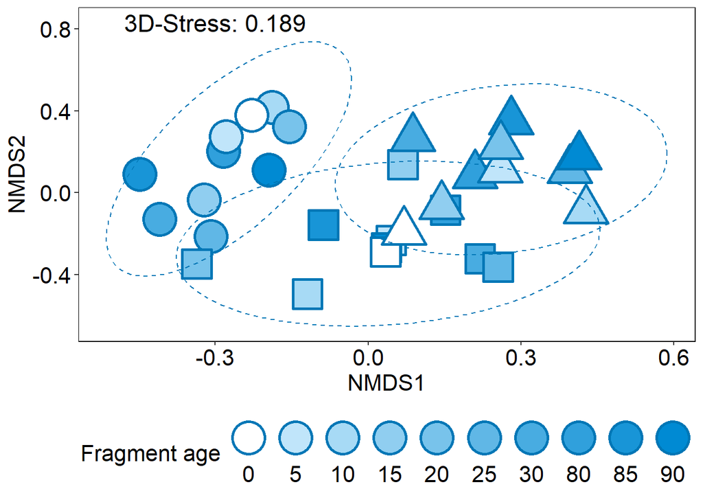

```r
DNA_method_ord_plot_1_2
```

```r
#____________________________________________________________________________________________________

#NMDS 1 and 3

DNA_method_ord_plot_1_3 <- DNA_method_ord_data %>%
  #Include a new variable for the plot
  mutate(Fragment_age_color = case_when(Fragment_age == "0" ~ "white",
                                        Fragment_age == "5" ~ "#C0E5FA",
                                        Fragment_age == "10" ~ "#A7DAF5",
                                        Fragment_age == "15" ~ "#90CEF0",
                                        Fragment_age == "20" ~ "#78C3EB",
                                        Fragment_age == "25" ~ "#60B7E6",
                                        Fragment_age == "30" ~ "#48ACE1",
                                        Fragment_age == "80" ~ "#30A0DC",
                                        Fragment_age == "85" ~ "#1895D7",
                                        Fragment_age == "90" ~ "#008AD3")) %>%
  #Select the data for plottiing
  ggplot(aes(x = NMDS1, y = NMDS3)) +
  #Select the type of plot
  geom_point(aes(shape = DNA_method, fill = Fragment_age), size = 10, show.legend = T, color = "#0077b6", stroke = 1.5) +
  #Select the shapes
  scale_shape_manual(values = c(21, 22, 24), name = "DNA extraction\nmethod", labels = c("PowerSoil Pro", "Decalcification\nPowerSoil Pro", "Decalcification\nAncient DNA")) +
    #Include the Stress inside the plot
  annotate(geom = "text", x = -0.3, y = 0.83, label = paste("3D-Stress:", signif(DNA_method_ord$stress, 3)), size = 6) +
  #Include the color selection
  scale_fill_manual(values = setNames(left_join(DNA_method_ord_data, DNA_method_ord_colors)$Fragment_age_color, left_join(DNA_method_ord_data, DNA_method_ord_colors)$Fragment_age) ) +
  #Include the elipses
  stat_ellipse(aes(color = DNA_method), linetype = "dashed", show.legend = F) +
  #Include colors
  scale_color_manual(values = c("#0077b6", "#0077b6", "#0077b6"))+
  #Choose which legends appear
  guides(color = "none",
         fill = "none") +
  #Include the stress value
#  labs(subtitle = paste("3D-Stress:", signif(DNA_method_ord$stress, 3))) +
  #Change the theme
  theme(panel.grid = element_blank(),
        panel.background = element_rect(fill = "white",  color = "black"),
        #Modify the caption size
        plot.subtitle = element_text(size = 16),
        #Modify the axis text
        axis.text = element_text(size = 16, color = "black"),
        axis.title = element_text(size = 16),
        #Modify the legend elements
        legend.position = "bottom",
        legend.key = element_rect(fill = "white", color = "white"),
        legend.title = element_text(color = "black", size = 16, hjust = 0.5), #Before size = 12
        legend.text = element_text(color = "black", size = 16), #Before size = 12
        #Include tags
        #plot.tag = element_text(face = "bold", size = 16),
        #plot.tag.location = "plot"
        )
```

```
## DNA_method, Location, Fragment_label, Fragment_age)`
## DNA_method, Location, Fragment_label, Fragment_age)`
```

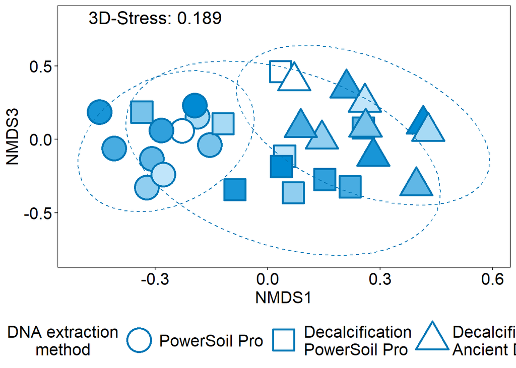

```r
DNA_method_ord_plot_1_3
```

```r
#____________________________________________________________________________________________________

#NMDS 1 and 3

DNA_method_ord_plot_2_3 <- DNA_method_ord_data %>%
  #Include a new variable for the plot
  mutate(Fragment_age_color = case_when(Fragment_age == "0" ~ "white",
                                        Fragment_age == "5" ~ "#C0E5FA",
                                        Fragment_age == "10" ~ "#A7DAF5",
                                        Fragment_age == "15" ~ "#90CEF0",
                                        Fragment_age == "20" ~ "#78C3EB",
                                        Fragment_age == "25" ~ "#60B7E6",
                                        Fragment_age == "30" ~ "#48ACE1",
                                        Fragment_age == "80" ~ "#30A0DC",
                                        Fragment_age == "85" ~ "#1895D7",
                                        Fragment_age == "90" ~ "#008AD3")) %>%
  #Select the data for plottiing
  ggplot(aes(x = NMDS2, y = NMDS3)) +
  #Select the type of plot
  geom_point(aes(shape = DNA_method, fill = Fragment_age), size = 10, show.legend = F, color = "#0077b6", stroke = 1.5) +
  #Select the shapes
  scale_shape_manual(values = c(21, 22, 24), name = "DNA extraction\nmethod", labels = c("PowerSoil Pro", "Decalcification\nPowerSoil Pro", "Decalcification\nAncient DNA")) +
    #Include the Stress inside the plot
  annotate(geom = "text", x = -0.46, y = 0.83, label = paste("3D-Stress:", signif(DNA_method_ord$stress, 3)), size = 6) +
  #Include the color selection
  scale_fill_manual(values = setNames(left_join(DNA_method_ord_data, DNA_method_ord_colors)$Fragment_age_color, left_join(DNA_method_ord_data, DNA_method_ord_colors)$Fragment_age) ) +
  #Include the elipses
  stat_ellipse(aes(color = DNA_method), linetype = "dashed", show.legend = F) +
  #Include colors
  scale_color_manual(values = c("#0077b6", "#0077b6", "#0077b6"))+
  #Include the stress value
#  labs(subtitle = paste("3D-Stress:", signif(DNA_method_ord$stress, 3))) +
  #Change the theme
  theme(panel.grid = element_blank(),
        panel.background = element_rect(fill = "white",  color = "black"),
        #Modify the caption size
        plot.subtitle = element_text(size = 16),
        #Modify the axis text
        axis.text = element_text(size = 16, color = "black"),
        axis.title = element_text(size = 16),
        #Modify the legend elements
        legend.position = "bottom",
        legend.key = element_rect(fill = "white", color = "white"),
        legend.title = element_text(color = "black", size = 16, hjust = 0.5), #Before size = 12
        legend.text = element_text(color = "black", size = 16), #Before size = 12
        #Include tags
        #plot.tag = element_text(face = "bold", size = 16),
        #plot.tag.location = "plot"
        )
```

```
## DNA_method, Location, Fragment_label, Fragment_age)`
## DNA_method, Location, Fragment_label, Fragment_age)`
```

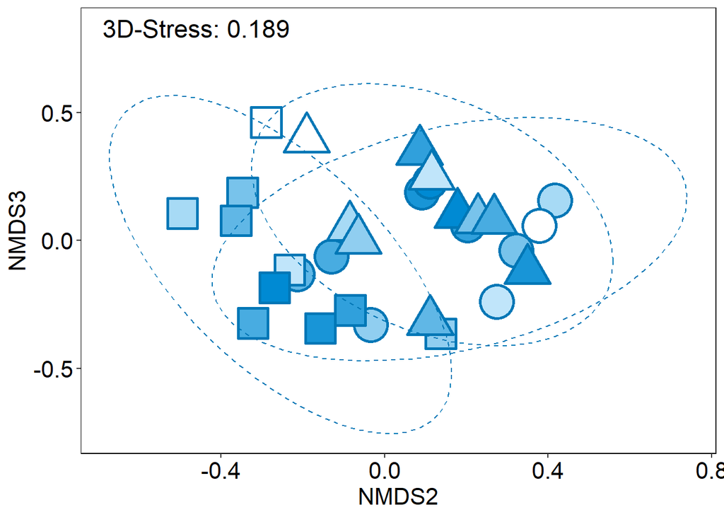

```r
DNA_method_ord_plot_2_3
```

### PERMANOVA

```r
#Create the datasets
##Distance matrix
DNA_method_dist <- vegdist(x = Abundance %>%
  #Obtain only Porites for PNG over 0.1%
  filter(Location == "PNG" & Coral_genus == "Porites" & Rel_abund_per > 0.1) %>%
  #Change the data structure: Rows are samples, columns are Post-MED sequences or Coral_genus DIV
  pivot_wider(id_cols = Sample_name, names_from = Symbiont_genus, values_from = Abundance, values_fill = 0) %>%
  #Assign sample names as row names for the vegdist function
  column_to_rownames(var = "Sample_name"),
  method = "bray")

##Metadata for distance matrix
DNA_method_dist_metadata <- Abundance %>%
  #Obtain only Porites for PNG over 0.1%
  filter(Location == "PNG" & Coral_genus == "Porites" & Rel_abund_per > 0.1) %>%
  #Change the data structure: Rows are samples, columns are Post-MED sequences or Coral_genus DIV
  pivot_wider(id_cols = Sample_name, names_from = Symbiont_genus, values_from = Abundance, values_fill = 0) %>%
  #Create a new metadata column with the DNA_methods
  mutate(DNA_method = factor(x = case_when(grepl(pattern = "D$", x = Sample_name, ignore.case = T) ~ "PowerSoil",
                              grepl(pattern = "E$", x = Sample_name, ignore.case = T) ~ "PowerSoil_EDTA",
                              grepl(pattern = "F$", x = Sample_name, ignore.case = T) ~ "Ancient_DNA"), levels = c("PowerSoil", "PowerSoil_EDTA", "Ancient_DNA")), .after = "Sample_name",

         Fragment_label = factor(x = case_when(grepl(pattern = "^[PD]0", x = Sample_name, ignore.case = T) ~ "Head",
                                           grepl(pattern = "^[PD]1[^678]", x = Sample_name, ignore.case = T) ~ "1",
                                           grepl(pattern = "^[PD]2[^012]", x = Sample_name, ignore.case = T) ~ "2",
                                           grepl(pattern = "^[PD]3", x = Sample_name, ignore.case = T) ~ "3",
                                           grepl(pattern = "^[PD]4", x = Sample_name, ignore.case = T) ~ "4",
                                           grepl(pattern = "^[PD]5", x = Sample_name, ignore.case = T) ~ "5",
                                           grepl(pattern = "^[PD]6", x = Sample_name, ignore.case = T) ~ "6",
                                           grepl(pattern = "P16", x = Sample_name, ignore.case = T) ~ "Anc1",
                                           grepl(pattern = "P17", x = Sample_name, ignore.case = T) ~ "Anc2",
                                           grepl(pattern = "P18", x = Sample_name, ignore.case = T) ~ "Anc3"), levels = c("Head", "1", "2", "3", "4", "5", "6", "Anc1", "Anc2", "Anc3"))) %>%
  #Assign sample names as row names for the adonis function
  column_to_rownames(var = "Sample_name")

#_____________________________________________________________________________

#Run the PERMANOVA

#Set the random seed
set.seed(15081998)
#Run the PERMANOVA - Only for DNA methods
adonis2(formula = DNA_method_dist ~ DNA_method, data = DNA_method_dist_metadata, permutations = 9999)
```

```
## Permutation test for adonis under reduced model
## Permutation: free
## Number of permutations: 9999
##
## adonis2(formula = DNA_method_dist ~ DNA_method, data = DNA_method_dist_metadata, permutations = 9999)
##          Df SumOfSqs      R2      F Pr(>F)
## Model     2   1.5086 0.11532 1.7597  1e-04 ***
## Residual 27  11.5739 0.88468
## Total    29  13.0825 1.00000
## ---
## Signif. codes:  0 '***' 0.001 '**' 0.01 '*' 0.05 '.' 0.1 ' ' 1
```

```r
#________________________________________________________________________________________________

#Test for multivariate homogeneity of variances
##Betadisper - general
anova(betadisper(DNA_method_dist, group = DNA_method_dist_metadata$DNA_method))
```

```
## Analysis of Variance Table
##
## Response: Distances
##           Df   Sum Sq    Mean Sq F value Pr(>F)
## Groups     2 0.001527 0.00076364  0.5064 0.6083
## Residuals 27 0.040717 0.00150805
```

```r
#________________________________________________________________________________________________

#Posthoc PERMANOVA
set.seed(15081998)
pairwise.adonis(x = DNA_method_dist, factors = DNA_method_dist_metadata$DNA_method)
```

[output not shown]

### UpSet plot

In order to inspect the number of shared Genus (DIV) between each DNA extraction method, an Upset plot was performed.

To create the UpSet plot we first need to group the data by DNA method (and Symbiodiniaceae) so that we can add the abundances per DIV. Then we create a logical variable based on the abundance of a DIV within each DNA extraction method.

For formatting the data we have to format the dataset so that we have the DNA method as columns, the DIVs as rows and the logical variable as the data.

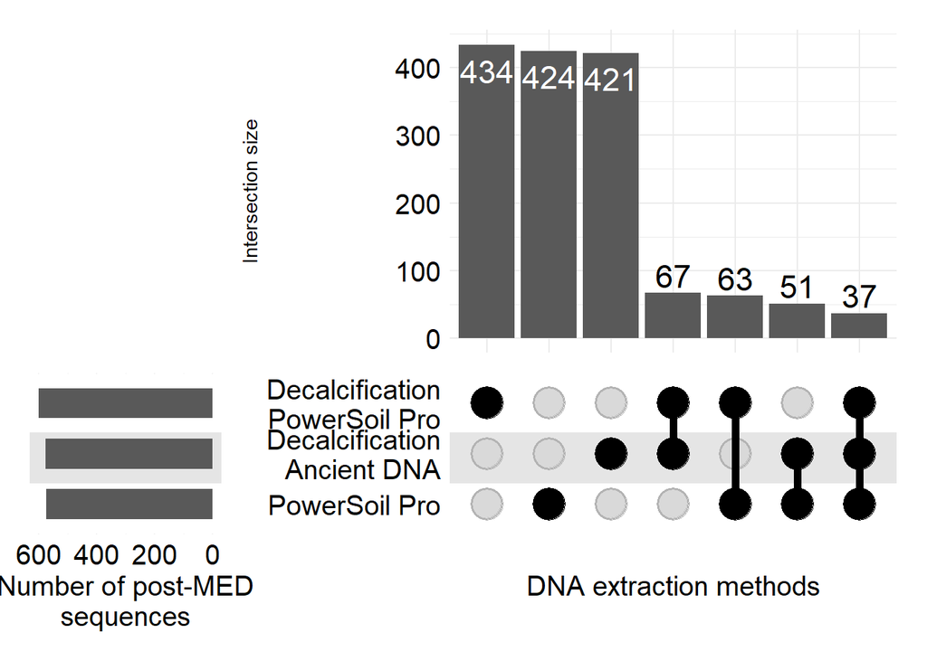

```r
##Go from long to wide format
DNA_Method_Upset_data <- as.data.frame(t(Abundance %>%
  #Filter to obtain the DNA extraction methods
  filter(Location == "PNG", Coral_genus == "Porites") %>%
  #Filter out DIVs with an abundance lower than 0.01
  filter(Rel_abund_per > 0.1) %>%
  #Group the data by DNA method
  group_by(DNA_method, Symbiont_genus) %>%
  #Calculate the sum the of the abundances
  summarize(Total_seqs = sum(Abundance)) %>%
  #Create a new Abundance variable that is only presence/abscense
  mutate(Abundance_logical = case_when(Total_seqs > 0 ~ 1,
                                       TRUE ~ 0)) %>%
  #Change the structure of the data
  pivot_wider(id_cols = DNA_method, names_from = Symbiont_genus, values_from = Abundance_logical, values_fill = 0) )) %>%
  #rownames to column
  rownames_to_column(var = "Symbiont_genus") %>%
  #row to column names
  rename(PowerSoil = V1, PowerSoil_EDTA = V2, Ancient_DNA = V3) %>%
  #Eliminate the first row
  filter(Symbiont_genus != "DNA_method") %>%
  #Transfrom data as numeric
  mutate(PowerSoil = as.numeric(PowerSoil), PowerSoil_EDTA = as.numeric(PowerSoil_EDTA), Ancient_DNA = as.numeric(Ancient_DNA)) %>%
  #Rename the variables for the plot
  rename("PowerSoil Pro" = "PowerSoil", "Decalcification\nPowerSoil Pro" = "PowerSoil_EDTA", "Decalcification\nAncient DNA" = "Ancient_DNA")
#_______________________________________________________________________

DNA_Method_Upset_plot <- upset(data = DNA_Method_Upset_data,
      #Groups
      intersect = c("PowerSoil Pro", "Decalcification\nPowerSoil Pro", "Decalcification\nAncient DNA"),
      #Change group names (x axis)
      name = "DNA extraction methods",
      #Modify the stripes
      stripes = upset_stripes(geom = geom_segment(size = 15), colors = c("white", "gray90")),
      #Modify the intersection matrix
      matrix = intersection_matrix(geom = geom_point(size = 7), segment = geom_segment(linewidth = 2)),
      #Modify the set size label
      set_sizes = (upset_set_size() + labs(y = "Number of post-MED\nsequences") + theme(axis.text.x = element_text(size = 15, color = "black"), axis.title.x = element_text(size = 15, color = "black") )
                   ),
      #Modify the intersection size area
      base_annotations = list("Intersection size" = intersection_size(text = list(size = 6)) + theme(axis.text.y = element_text(size = 15, color = "black"))
                              ),
      #Group the plot so that it is easier to combine with other plots
      wrap = T,
      #Change the theme elements
      themes =

      upset_modify_themes(list("intersections_matrix" = theme(axis.text.y = element_text(size = 15, color = "black"),
                                                              axis.title.x = element_text(size = 15, color = "black"),
                                                              panel.grid = element_blank()),

                               "intersection_size" = theme(axis.title.y = element_text(size = 16, color = "black"),
                                                             panel.grid = element_blank()) )) )
DNA_Method_Upset_plot
```

```r
#ggsave(plot = DNA_Method_Upset_0.1_plot_ComplexUpset, filename = "DNA_method_Upset.png", width = 200, height = 180, units = "mm", dpi = 1800)
#ggsave(plot = DNA_Method_Upset_0.1_plot_ComplexUpset, filename = "DNA_method_Upset.svg", width = 200, height = 180, units = "mm", dpi = 1800)
```

### Joint plots

[figure not shown]

```r
DNA_method_plot_layout <- "
AAABBB
CCC###
DDEEFF
GGGHHH"

#Extract the legend from the bar plot
DNA_method_bar_plot_legend <- ggpubr::as_ggplot(ggpubr::get_legend(DNA_method_bar_plot))

#Extract the shape legend from the NMDS plots
DNA_method_ord_plot_1_2_legend <- ggpubr::as_ggplot(ggpubr::get_legend(DNA_method_ord_plot_1_2))

#Extract the color legend from the NMDS plots
DNA_method_ord_plot_1_3_legend <- ggpubr::as_ggplot(ggpubr::get_legend(DNA_method_ord_plot_1_3))

#Craft the plot
Figure_2 <- DNA_method_bar_plot + DNA_Method_Upset_plot + DNA_method_bar_plot_legend +
  DNA_method_ord_plot_1_2 + DNA_method_ord_plot_1_3 + DNA_method_ord_plot_2_3 +
  DNA_method_ord_plot_1_2_legend + DNA_method_ord_plot_1_3_legend +
  #Modify the plot heights
  plot_layout(design = DNA_method_plot_layout,
    heights = c(1, 0.1, 1, 0.1) ) + plot_annotation(#tag_prefix = "(", tag_suffix = ")",
      tag_levels = list(c("(a)", "(b)", "", "(c)", "(d)", "(e)", "", ""))) & theme(plot.tag = element_text(size = 20, face = "bold"), legend.position = "none", plot.tag.position = c(0.05, 1))

Figure_2
```

```r
#ggsave(filename = "Figures/Figure_2.pdf", width = 400, height = 350, units = "mm", dpi = 1800)
#ggsave(filename = "Figures/Figure_2.png", width = 400, height = 350, units = "mm", dpi = 1800)
#ggsave(filename = "Figures/Figure_2.svg", width = 400, height = 350, units = "mm", dpi = 1800)
```

## Aim 2 - Species x Location effects

### Bar plots

We visualized relative abundance of the post-MED sequences through a stacked bar plot.

> NOTE: The relative abundance *under* 0.1% was included as the “Others” category

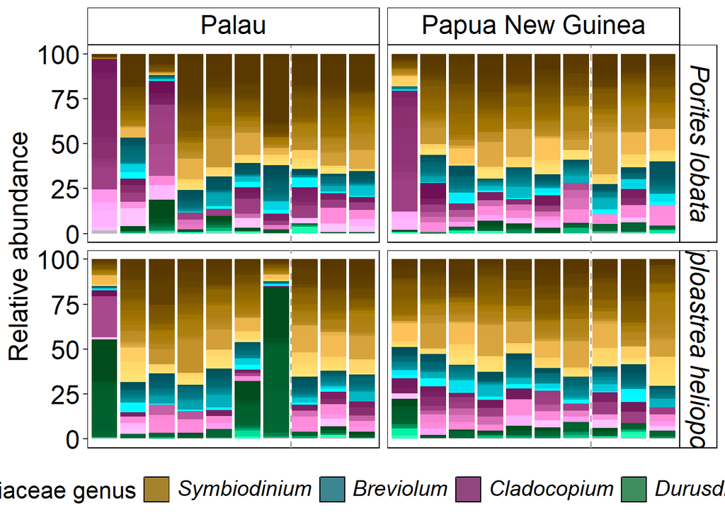

```r
Location_species_bar_plot <- Abundance %>%
  #Select the PNG Porites samples
  filter(DNA_method == "PowerSoil_EDTA") %>%
  #Create a new DNA_method variable for plotting
  mutate(DNA_method_plot = factor(x = DNA_method, levels = c("PowerSoil", "PowerSoil_EDTA", "Ancient_DNA"), labels = c("PowerSoil Pro", "Decalcification\nPowerSoil Pro", "Decalcification\nAncient DNA"))) %>%
  #Create a new species and Location variable for the plot
  mutate(Location_plot = factor(x = case_when(Location == "PNG" ~ "Papua New Guinea",
                                   TRUE ~ Location), levels = c("Palau", "Papua New Guinea")),

         Coral_genus_plot = factor(x = case_when(Coral_genus == "Porites" ~ "*Porites lobata*",
                                Coral_genus == "Diploastrea" ~ "*Diploastrea heliopora*"),
                             levels = c("*Porites lobata*", "*Diploastrea heliopora*")),

         Fragment_label_plot = factor(x = case_when(Fragment_label == "Head" ~ "0",
                                                    TRUE ~ Fragment_label),
                                      levels = c("0", "1", "2", "3", "4", "5", "6", "Anc1", "Anc2", "Anc3"),
                                      labels = c("0", "5", "10", "15", "20", "25", "30", "Anc1", "Anc2", "Anc3")) ) %>%
  #Select the data for the plot
  ggplot() +

  # First geom_col for the fill aesthetic (stacked bars)
  geom_col(aes(x = Fragment_label_plot, y = Rel_abund_per,
               fill = Symbiont_genus_combined_others),
           color = NA, show.legend = FALSE) +  # Hide color here to prevent duplication

  # Second geom_col for the color aesthetic (transparent borders)
  geom_col(data = Abundance %>%
  #Select the DNA method
  filter(DNA_method == "PowerSoil_EDTA") %>%
  #Create a new DNA_method variable for plotting
  mutate(DNA_method_plot = factor(x = DNA_method, levels = c("PowerSoil", "PowerSoil_EDTA", "Ancient_DNA"), labels = c("PowerSoil Pro", "Decalcification\nPowerSoil Pro", "Decalcification\nAncient DNA")),

         Symbiont_genus_simp_others_plot = factor(x = case_when(Symbiont_genus_simp_others == "A" ~ "*Symbiodinium*",
                                                       Symbiont_genus_simp_others == "B" ~ "*Breviolum*",
                                                       Symbiont_genus_simp_others == "C" ~ "*Cladocopium*",
                                                       Symbiont_genus_simp_others == "D" ~ "*Durusdinium*",
                                                       Symbiont_genus_simp_others == "Others" ~ "Others"), levels = c("*Symbiodinium*", "*Breviolum*", "*Cladocopium*", "*Durusdinium*", "Others")),

         Fragment_label_plot = factor(x = case_when(Fragment_label == "Head" ~ "0",
                                                    TRUE ~ Fragment_label),
                                      levels = c("0", "1", "2", "3", "4", "5", "6", "Anc1", "Anc2", "Anc3"),
                                      labels = c("0", "5", "10", "15", "20", "25", "30", "Anc1", "Anc2", "Anc3")) ) %>%
    #Create a new species and Location variable for the plot
  mutate(Location_plot = factor(x = case_when(Location == "PNG" ~ "Papua New Guinea",
                                   TRUE ~ Location), levels = c("Palau", "Papua New Guinea")),

         Coral_genus_plot = factor(x = case_when(Coral_genus == "Porites" ~ "*Porites lobata*",
                                Coral_genus == "Diploastrea" ~ "*Diploastrea heliopora*"),
                             levels = c("*Porites lobata*", "*Diploastrea heliopora*"),
                             labels = c("*Porites lobata*", "*Diploastrea heliopora*"))) ,

           aes(x = Fragment_label_plot, y = Rel_abund_per,
               color = Symbiont_genus_simp_others_plot),
           fill = NA, alpha = 0, show.legend = TRUE) +

  #Include the scale_manual
  scale_fill_manual(values = setNames(as.character(subset(x = Abundance, subset = DNA_method == "PowerSoil_EDTA")$Symbiont_genus_color_others), as.character(subset(x = Abundance, subset = DNA_method == "PowerSoil_EDTA")$Symbiont_genus_combined_others))) +
  #Include the colors
  scale_color_manual(values = c("transparent", "transparent", "transparent", "transparent", "transparent"),  name = "Symbiodiniaceae genus") +
  #Change the legend
  guides(fill = "none",
          color = guide_legend(override.aes = list(
    fill = c("#a5822d", "#3d8590", "#91467f", "#408e5e", "#bbbbbb"),
    color = c("#a5822d", "#3d8590", "#91467f", "#408e5e", "#bbbbbb"),
    alpha = 1)) )  +
  #Include facets
  facet_grid(rows = vars(Coral_genus_plot), cols = vars(Location_plot), scales = "free") +
  #Include a vertical line to indicate the ancient samples
  geom_vline(xintercept = 7.5, linetype = "dashed", linewidth = 0.7, color = "darkgray") +
  #Include plot title
  labs(x = "Fragment age (Years)", y = "Relative abundance") +
  #Modify the theme
  theme(
    #Eliminate panel grids
    panel.grid = element_blank(),
    #Change background color
    panel.background = element_rect(fill = "white", color = "black"),
    #Increase axes label text size
    axis.text.x = element_text(color = "white", size = 1), #Before size = 10
    axis.title.x = element_blank(),
    axis.ticks.x = element_blank(),
    axis.text.y = element_text(color = "black", size = 18), #Before size = 12
    axis.title.y = element_text(color = "black", size = 18), #Before size = 13
    #Change the color of the facet label
    strip.background = element_rect(fill = "white", color = "black"),
    #Increase facet label text size
    strip.text.x = ggtext::element_markdown(color = "black", size = 18), #Before size = 12
    strip.text.y = ggtext::element_markdown(color = "black", size = 18), #Before size = 12
    #Change the legend
    legend.title = element_text(color = "black", size = 16, hjust = 0.5), #Before size = 14
    legend.text = ggtext::element_markdown(color = "black", size = 15), #Before size = 13
    legend.position = "bottom",
    #Include tags
    plot.tag = element_text(face = "bold", size = 16),
    plot.tag.location = "plot"
    )

Location_species_bar_plot
```

```r
#ggsave(filename = "Location_species_bar_plot.png", width = 200, height = 200, units = "mm", dpi = 1500)
```

> NOTE: This plot will be combined with the Bleaching alert data explored in Aim 3

### NMDS plots

To visualize the community structure we performed a NMDS based on Bray-Curtis distances of the post-MED sequences.

> NOTE: We filtered the relative abundance under 0.1%

```r
#Create the datasets

#Ordination
##Set the random seed
set.seed(15081998)
Location_species_ord_all <- metaMDS(comm = Abundance %>% filter(DNA_method == "PowerSoil_EDTA" & Rel_abund_per > 0.1) %>% pivot_wider(id_cols = Sample_name, names_from = Symbiont_genus, values_from = Abundance, values_fill = 0) %>% column_to_rownames(var = "Sample_name"), dist = "bray", k = 3)
```

```
## Square root transformation
## Wisconsin double standardization
## *** Best solution repeated 1 times
```

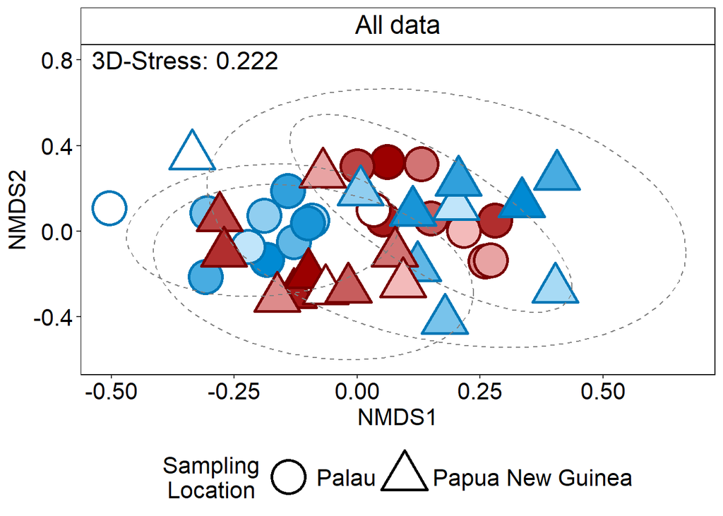

```r
#Extract the data
Location_species_ord_all_data <- as.data.frame(scores(Location_species_ord_all)$sites)

##Include the metadata
Location_species_ord_all_data <- Location_species_ord_all_data %>%
  #Include sample names
  rownames_to_column(var = "Sample_name") %>%
  #Include the Location, Species and DNA_Method
  mutate(

         Coral_genus = factor(x = case_when(grepl(pattern = "^P", x = Sample_name, ignore.case = T) ~ "Porites",
                           grepl(pattern = "^D", x = Sample_name, ignore.case = T) ~ "Diploastrea"), levels = c("Porites", "Diploastrea")),


         Coral_genus_fill_aes = factor(x = case_when(grepl(pattern = "^P", x = Sample_name, ignore.case = T) ~ "Porites",
                           grepl(pattern = "^D", x = Sample_name, ignore.case = T) ~ "Diploastrea"), levels = c("Porites", "Diploastrea"), labels = c(21, 24)),


         #DNA extraction method
         DNA_method = factor(x = case_when(grepl(pattern = "B$", x = Sample_name, ignore.case = T) ~ "PowerSoil_EDTA",
                              grepl(pattern = "D$", x = Sample_name, ignore.case = T) ~ "PowerSoil",
                              grepl(pattern = "E$", x = Sample_name, ignore.case = T) ~ "PowerSoil_EDTA",
                              grepl(pattern = "F$", x = Sample_name, ignore.case = T) ~ "Ancient_DNA"), levels = c("PowerSoil", "PowerSoil_EDTA", "Ancient_DNA")),


         #Sampling location
         Location = factor(x = case_when(grepl(pattern = "B$", x = Sample_name, ignore.case = T) ~ "Palau",
                              grepl(pattern = "D$", x = Sample_name, ignore.case = T) ~ "PNG",
                              grepl(pattern = "E$", x = Sample_name, ignore.case = T) ~ "PNG",
                              grepl(pattern = "F$", x = Sample_name, ignore.case = T) ~ "PNG"), levels = c("Palau", "PNG")),


         Location_shape_aes = factor(x = case_when(grepl(pattern = "B$", x = Sample_name, ignore.case = T) ~ "Palau",
                              grepl(pattern = "D$", x = Sample_name, ignore.case = T) ~ "PNG",
                              grepl(pattern = "E$", x = Sample_name, ignore.case = T) ~ "PNG",
                              grepl(pattern = "F$", x = Sample_name, ignore.case = T) ~ "PNG"), levels = c("Palau", "PNG"), labels = c(21,24)),


         #Number asociated with each fragment
         Fragment_label = factor(x = case_when(grepl(pattern = "^[PD]0", x = Sample_name, ignore.case = T) ~ "Head",
                                           grepl(pattern = "^[PD]1[^678]", x = Sample_name, ignore.case = T) ~ "1",
                                           grepl(pattern = "^[PD]2[^012]", x = Sample_name, ignore.case = T) ~ "2",
                                           grepl(pattern = "^[PD]3", x = Sample_name, ignore.case = T) ~ "3",
                                           grepl(pattern = "^[PD]4", x = Sample_name, ignore.case = T) ~ "4",
                                           grepl(pattern = "^[PD]5", x = Sample_name, ignore.case = T) ~ "5",
                                           grepl(pattern = "^[PD]6", x = Sample_name, ignore.case = T) ~ "6",
                                           grepl(pattern = "P16", x = Sample_name, ignore.case = T) ~ "Anc1",
                                           grepl(pattern = "P17", x = Sample_name, ignore.case = T) ~ "Anc2",
                                           grepl(pattern = "P18", x = Sample_name, ignore.case = T) ~ "Anc3",
                                           grepl(pattern = "D20", x = Sample_name, ignore.case = T) ~ "Anc1",
                                           grepl(pattern = "D21", x = Sample_name, ignore.case = T) ~ "Anc2",
                                           grepl(pattern = "D22", x = Sample_name, ignore.case = T) ~ "Anc3"), levels = c("Head", "1", "2", "3", "4", "5", "6", "Anc1", "Anc2", "Anc3")),

         #Fragment age
         Fragment_age = factor(x = case_when(grepl(pattern = "^[PD]0", x = Sample_name, ignore.case = T) ~ "0",
                                           grepl(pattern = "^[PD]1[^678]", x = Sample_name, ignore.case = T) ~ "5",
                                           grepl(pattern = "^[PD]2[^012]", x = Sample_name, ignore.case = T) ~ "10",
                                           grepl(pattern = "^[PD]3", x = Sample_name, ignore.case = T) ~ "15",
                                           grepl(pattern = "^[PD]4", x = Sample_name, ignore.case = T) ~ "20",
                                           grepl(pattern = "^[PD]5", x = Sample_name, ignore.case = T) ~ "25",
                                           grepl(pattern = "^[PD]6", x = Sample_name, ignore.case = T) ~ "30",
                                           grepl(pattern = "P16", x = Sample_name, ignore.case = T) ~ "80",
                                           grepl(pattern = "P17", x = Sample_name, ignore.case = T) ~ "85",
                                           grepl(pattern = "P18", x = Sample_name, ignore.case = T) ~ "90",
                                           grepl(pattern = "D20", x = Sample_name, ignore.case = T) ~ "100",
                                           grepl(pattern = "D21", x = Sample_name, ignore.case = T) ~ "105",
                                           grepl(pattern = "D22", x = Sample_name, ignore.case = T) ~ "110"), levels = c("0", "5", "10", "15", "20", "25", "30", "80", "85", "90", "100", "105", "110")) )

#_____________________________________

#Assign colors

Location_species_ord_all_data_colors <- ggnested::extract_palette(  Location_species_ord_all_data %>% ggnested::ggnested(aes(x = NMDS1, y = NMDS2, fill = Coral_genus, main_group = Coral_genus, sub_group = Fragment_age), main_palette = c("#0077b6", "#780000"), gradient_type = "tints") +  geom_point(aes(shape = Location), size = 10) + scale_shape_manual(values = c(21, 24)) + geom_text(aes(label = Fragment_age), color = "white",  fontface = "bold") + labs(title = "Palau - Porites - Rel abund over 0.1%", subtitle = paste("Bray-Curtis distance, Stress: ", signif(Location_species_ord_all$stress, 3))) + theme(panel.grid = element_blank(), panel.background = element_rect(fill = "white",  color = "black"), legend.position = "bottom") ) %>%
  #Obtain unique columns for Coral_genus DIV and Symbiont_genus_simp
  separate(col = group_subgroup, into = c("Coral_genus", "Fragment_age"), sep = " - ", remove = F) %>%
  #Rename variables
  rename(Coral_genus_Frag_age = group_subgroup, Coral_genus_color = group_colour, Fragment_age_color = subgroup_colour) %>%
  #Modify the Fragment age variable to change the head as white
  mutate(Fragment_age_color = case_when(Coral_genus_Frag_age == "Porites - 0" ~ "white", #"#D8F1FF"
                                        Coral_genus_Frag_age == "Porites - 5" ~ "#C0E5FA",
                                        Coral_genus_Frag_age == "Porites - 10" ~ "#A7DAF5",
                                        Coral_genus_Frag_age == "Porites - 15" ~ "#90CEF0",
                                        Coral_genus_Frag_age == "Porites - 20" ~ "#78C3EB",
                                        Coral_genus_Frag_age == "Porites - 25" ~ "#60B7E6",
                                        Coral_genus_Frag_age == "Porites - 30" ~ "#48ACE1",
                                        Coral_genus_Frag_age == "Porites - 80" ~ "#30A0DC",
                                        Coral_genus_Frag_age == "Porites - 85" ~ "#1895D7",
                                        Coral_genus_Frag_age == "Porites - 90" ~ "#008AD3",

                                        Coral_genus_Frag_age == "Diploastrea - 0" ~ "white", #"#FFD2D2"
                                        Coral_genus_Frag_age == "Diploastrea - 5" ~ "#F3BABA",
                                        Coral_genus_Frag_age == "Diploastrea - 10" ~ "#E8A3A3",
                                        Coral_genus_Frag_age == "Diploastrea - 15" ~ "#DD8B8B",
                                        Coral_genus_Frag_age == "Diploastrea - 20" ~ "#D27474",
                                        Coral_genus_Frag_age == "Diploastrea - 25" ~ "#C75D5D",
                                        Coral_genus_Frag_age == "Diploastrea - 30" ~    "#BC4545",
                                        Coral_genus_Frag_age == "Diploastrea - 100" ~   "#B12E2E",
                                        Coral_genus_Frag_age == "Diploastrea - 105" ~   "#A61717",
                                        Coral_genus_Frag_age == "Diploastrea - 110" ~   "#9B0000"))
#_____________________________________

#Plot the nMDS

#NMDS1 - NMDS2

Location_species_ord_all_plot <- left_join(Location_species_ord_all_data, Location_species_ord_all_data_colors, by = c("Coral_genus", "Fragment_age")) %>%
  #Include new variable for plotting
  unite(col = "Location_genus", Location, Coral_genus, sep = "_", remove = F) %>%
  #Include plotting variables
  mutate(Location_plot = factor(x = Location, levels = c("Palau", "PNG"), labels = c("Palau", "Papua New Guinea")),
         Facet_label = "All data") %>%
  #Select the data for plotting
  ggplot(aes(x = NMDS1, y = NMDS2)) +
  #Select the type of plot
  geom_point(aes(fill = Coral_genus_Frag_age, shape = Location_plot, color = Coral_genus_Frag_age), size = 10, show.legend = T, stroke = 1.5) +
  #Include the shape selection
  scale_shape_manual(values = c(21, 24), name = "Sampling\nLocation") +
  #Include the elipses
  stat_ellipse(aes(color = Location_genus), linetype = "dashed", show.legend = F,
               #color = c("#0077b6", "#780000")
               ) +
  #Include the color selection
  scale_fill_manual(values = setNames(as.character(left_join(Location_species_ord_all_data, Location_species_ord_all_data_colors, by = c("Coral_genus", "Fragment_age"))$Fragment_age_color), as.character(left_join(Location_species_ord_all_data, Location_species_ord_all_data_colors, by = c("Coral_genus", "Fragment_age"))$Coral_genus_Frag_age)) ) +
  #Include the color selection for borders
  scale_color_manual(values = setNames(left_join(Location_species_ord_all_data, Location_species_ord_all_data_colors, by = c("Coral_genus", "Fragment_age"))$Coral_genus_color, left_join(Location_species_ord_all_data, Location_species_ord_all_data_colors, by = c("Coral_genus", "Fragment_age"))$Coral_genus_Frag_age) ) +
  #Choose which legends appear
  guides(color = "none",
         fill = "none") +
    #Include the Stress inside the plot
  annotate(geom = "text", x = -0.35, y = 0.8, label = paste("3D-Stress:", signif(Location_species_ord_all$stress, 3)), size = 6) +
  #Include the Stress value
#  labs(subtitle = paste("3D-Stress:", signif(Location_species_ord_all$stress, 3))) +
  #Include facet grid name
  facet_grid(cols = vars(Facet_label)) +
  #Modify the theme
  theme(panel.grid = element_blank(),
        panel.background = element_rect(fill = "white",  color = "black"),
        #Modify the caption size
        plot.subtitle = element_text(size = 16),
        #Modify the axis text
        axis.text = element_text(size = 16, color = "black"),
        axis.title = element_text(size = 16, color = "black"),
        #Modify the legend elements
        legend.position = "bottom",
        legend.key = element_rect(fill = "white", color = "white"),
        legend.title = element_text(color = "black", size = 16, hjust = 0.5), #Before size = 12
        legend.text = element_text(color = "black", size = 16), #Before size = 12
        #Include tags
        plot.tag = element_text(face = "bold", size = 20),
        plot.tag.location = "plot",
        #Change the color of the facet label
        strip.background = element_rect(fill = "white", color = "black"),
        #Increase facet label text size
        strip.text = ggtext::element_markdown(color = "black", size = 18)
        )


Location_species_ord_all_plot
```

```r
#Palau

#Create the datasets

#Ordination
##Set the random seed
set.seed(15081998)
Palau_ord <- metaMDS(comm = Abundance %>% filter(Location == "Palau" & DNA_method == "PowerSoil_EDTA" & Rel_abund_per > 0.1) %>% pivot_wider(id_cols = Sample_name, names_from = Symbiont_genus, values_from = Abundance, values_fill = 0) %>% column_to_rownames(var = "Sample_name"), dist = "bray")
```

```
## Square root transformation
## Wisconsin double standardization
## *** Best solution repeated 4 times
```

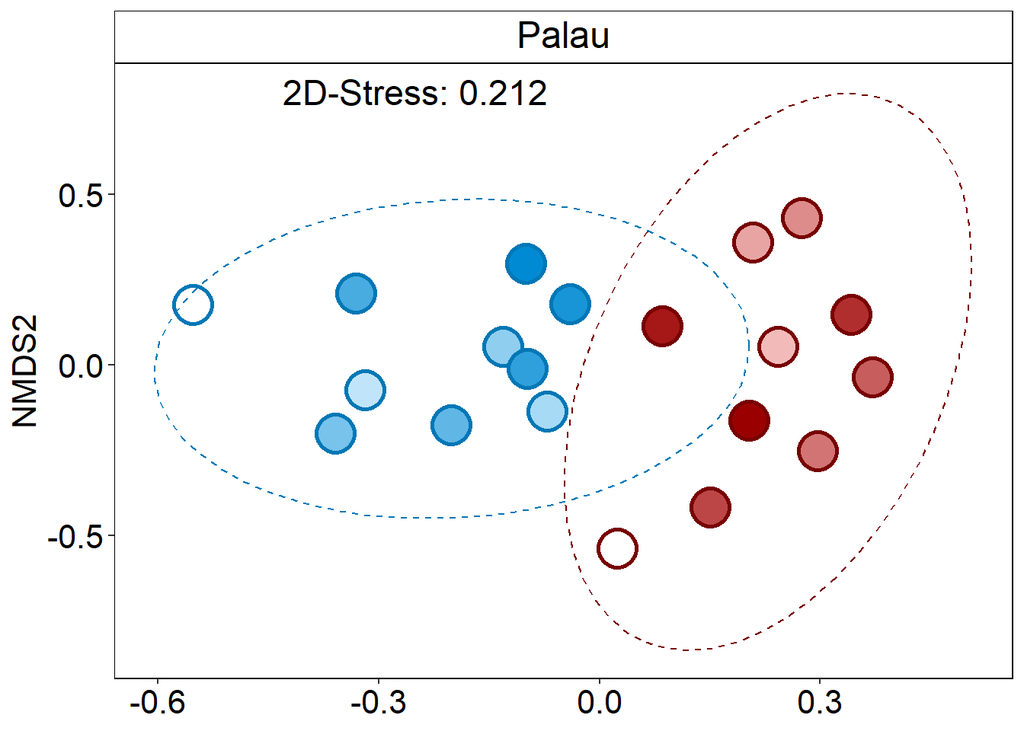

```r
#Extract the data
Palau_ord_data <- as.data.frame(scores(Palau_ord)$sites) %>%
  #Include sample names
  rownames_to_column(var = "Sample_name") %>%
  #Include the Location, Species and DNA_Method
  mutate(Coral_genus = factor(x = case_when(grepl(pattern = "^P", x = Sample_name, ignore.case = T) ~ "Porites",
                           grepl(pattern = "^D", x = Sample_name, ignore.case = T) ~ "Diploastrea"), levels = c("Porites", "Diploastrea")),


         Coral_genus_fill_aes = factor(x = case_when(grepl(pattern = "^P", x = Sample_name, ignore.case = T) ~ "Porites",
                           grepl(pattern = "^D", x = Sample_name, ignore.case = T) ~ "Diploastrea"), levels = c("Porites", "Diploastrea"), labels = c(21, 24)),


         #DNA extraction method
         DNA_method = factor(x = case_when(grepl(pattern = "B$", x = Sample_name, ignore.case = T) ~ "PowerSoil_EDTA",
                              grepl(pattern = "D$", x = Sample_name, ignore.case = T) ~ "PowerSoil",
                              grepl(pattern = "E$", x = Sample_name, ignore.case = T) ~ "PowerSoil_EDTA",
                              grepl(pattern = "F$", x = Sample_name, ignore.case = T) ~ "Ancient_DNA"), levels = c("PowerSoil", "PowerSoil_EDTA", "Ancient_DNA")),


         #Sampling location
         Location = factor(x = case_when(grepl(pattern = "B$", x = Sample_name, ignore.case = T) ~ "Palau",
                              grepl(pattern = "D$", x = Sample_name, ignore.case = T) ~ "PNG",
                              grepl(pattern = "E$", x = Sample_name, ignore.case = T) ~ "PNG",
                              grepl(pattern = "F$", x = Sample_name, ignore.case = T) ~ "PNG"), levels = c("Palau", "PNG")),


         Location_shape_aes = factor(x = case_when(grepl(pattern = "B$", x = Sample_name, ignore.case = T) ~ "Palau",
                              grepl(pattern = "D$", x = Sample_name, ignore.case = T) ~ "PNG",
                              grepl(pattern = "E$", x = Sample_name, ignore.case = T) ~ "PNG",
                              grepl(pattern = "F$", x = Sample_name, ignore.case = T) ~ "PNG"), levels = c("Palau", "PNG"), labels = c(21,24)),


         #Number asociated with each fragment
         Fragment_label = factor(x = case_when(grepl(pattern = "^[PD]0", x = Sample_name, ignore.case = T) ~ "Head",
                                           grepl(pattern = "^[PD]1[^678]", x = Sample_name, ignore.case = T) ~ "1",
                                           grepl(pattern = "^[PD]2[^012]", x = Sample_name, ignore.case = T) ~ "2",
                                           grepl(pattern = "^[PD]3", x = Sample_name, ignore.case = T) ~ "3",
                                           grepl(pattern = "^[PD]4", x = Sample_name, ignore.case = T) ~ "4",
                                           grepl(pattern = "^[PD]5", x = Sample_name, ignore.case = T) ~ "5",
                                           grepl(pattern = "^[PD]6", x = Sample_name, ignore.case = T) ~ "6",
                                           grepl(pattern = "P16", x = Sample_name, ignore.case = T) ~ "Anc1",
                                           grepl(pattern = "P17", x = Sample_name, ignore.case = T) ~ "Anc2",
                                           grepl(pattern = "P18", x = Sample_name, ignore.case = T) ~ "Anc3",
                                           grepl(pattern = "D20", x = Sample_name, ignore.case = T) ~ "Anc1",
                                           grepl(pattern = "D21", x = Sample_name, ignore.case = T) ~ "Anc2",
                                           grepl(pattern = "D22", x = Sample_name, ignore.case = T) ~ "Anc3"), levels = c("Head", "1", "2", "3", "4", "5", "6", "Anc1", "Anc2", "Anc3")),

         #Fragment age
         Fragment_age = factor(x = case_when(grepl(pattern = "^[PD]0", x = Sample_name, ignore.case = T) ~ "0",
                                           grepl(pattern = "^[PD]1[^678]", x = Sample_name, ignore.case = T) ~ "5",
                                           grepl(pattern = "^[PD]2[^012]", x = Sample_name, ignore.case = T) ~ "10",
                                           grepl(pattern = "^[PD]3", x = Sample_name, ignore.case = T) ~ "15",
                                           grepl(pattern = "^[PD]4", x = Sample_name, ignore.case = T) ~ "20",
                                           grepl(pattern = "^[PD]5", x = Sample_name, ignore.case = T) ~ "25",
                                           grepl(pattern = "^[PD]6", x = Sample_name, ignore.case = T) ~ "30",
                                           grepl(pattern = "P16", x = Sample_name, ignore.case = T) ~ "80",
                                           grepl(pattern = "P17", x = Sample_name, ignore.case = T) ~ "85",
                                           grepl(pattern = "P18", x = Sample_name, ignore.case = T) ~ "90",
                                           grepl(pattern = "D20", x = Sample_name, ignore.case = T) ~ "100",
                                           grepl(pattern = "D21", x = Sample_name, ignore.case = T) ~ "105",
                                           grepl(pattern = "D22", x = Sample_name, ignore.case = T) ~ "110"), levels = c("0", "5", "10", "15", "20", "25", "30", "80", "85", "90", "100", "105", "110")) )

#_____________________________________

#Plot the nMDS

Palau_ord_plot <- left_join(Palau_ord_data, Location_species_ord_all_data_colors, by = c("Coral_genus", "Fragment_age")) %>%
  #Select the data for plotting
  ggplot(aes(x = NMDS1, y = NMDS2)) +
  #Select the type of plot
  geom_point(aes(fill = Coral_genus_Frag_age, color = Coral_genus), shape = 21, size = 8, show.legend = F, stroke = 1.5) +
  #Include the elipses
  stat_ellipse(aes(color = Coral_genus), linetype = "dashed", show.legend = F,
               #color = c("#0077b6", "#780000")
               ) +
  #Include the color selection
  scale_fill_manual(values = setNames(
    left_join(Palau_ord_data, Location_species_ord_all_data_colors, by = c("Coral_genus", "Fragment_age"))$Fragment_age_color,
    left_join(Palau_ord_data, Location_species_ord_all_data_colors, by = c("Coral_genus", "Fragment_age"))$Coral_genus_Frag_age)) +
  #Include the color selection
  scale_color_manual(values = setNames(
    left_join(Palau_ord_data, Location_species_ord_all_data_colors, by = c("Coral_genus", "Fragment_age"))$Coral_genus_color,
    left_join(Palau_ord_data, Location_species_ord_all_data_colors, by = c("Coral_genus", "Fragment_age"))$Coral_genus)) +
  #Include facet for the title
  facet_grid(cols = vars(Location)) +
  #Include the Stress value
  labs(x = NULL
    #subtitle = paste("2D-Stress:", signif(Palau_ord$stress, 3))
    ) +
  #Include the Stress inside the plot
  annotate(geom = "text", x = -0.25, y = 0.8, label = paste("2D-Stress:", signif(Palau_ord$stress, 3)), size = 6) +
  #Modify the theme
  theme(panel.grid = element_blank(),
      panel.background = element_rect(fill = "white",  color = "black"),
      #Modify the caption size
      plot.subtitle = element_text(size = 16),
      #Modify the axis text
      axis.text = element_text(size = 16, color = "black"),
      axis.title = element_text(size = 16, color = "black"),
      #Modify the legend elements
      legend.position = "bottom",
      legend.key = element_rect(fill = "white", color = "white"),
      legend.title = element_text(color = "black", size = 16, hjust = 0.5), #Before size = 12
      legend.text = element_text(color = "black", size = 16), #Before size = 12
      #Change the color of the facet label
      strip.background = element_rect(fill = "white", color = "black"),
      #Increase facet label text size
      strip.text = ggtext::element_markdown(color = "black", size = 18)
      )

Palau_ord_plot
```

```r
#________________________________________________________________________________________

#PNG

#Create the datasets

#Ordination
##Set the random seed
set.seed(15081998)
PNG_ord <- metaMDS(comm = Abundance %>% filter(Location == "PNG" & DNA_method == "PowerSoil_EDTA" & Rel_abund_per > 0.1) %>% pivot_wider(id_cols = Sample_name, names_from = Symbiont_genus, values_from = Abundance, values_fill = 0) %>% column_to_rownames(var = "Sample_name"), dist = "bray")
```

```
## Square root transformation
## Wisconsin double standardization
## *** Best solution was not repeated -- monoMDS stopping criteria:
##     20: stress ratio > sratmax
```

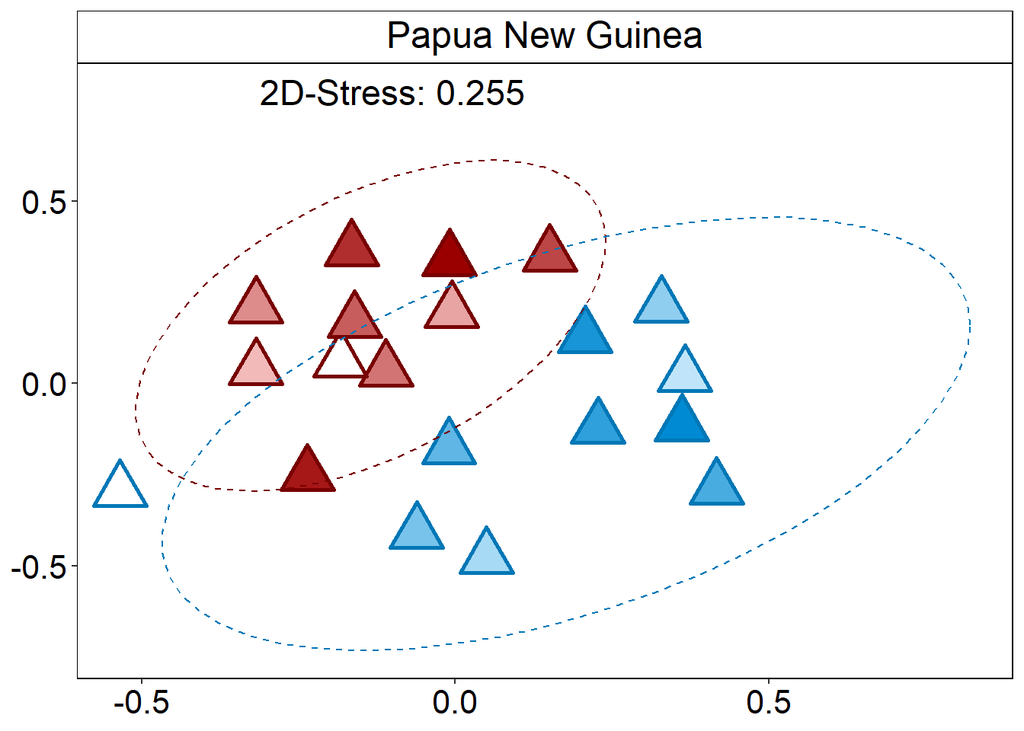

```r
#Extract the data
PNG_ord_data <- as.data.frame(scores(PNG_ord)$sites) %>%
  #Include sample names
  rownames_to_column(var = "Sample_name") %>%
  #Include the Location, Species and DNA_Method
  mutate(Coral_genus = factor(x = case_when(grepl(pattern = "^P", x = Sample_name, ignore.case = T) ~ "Porites",
                           grepl(pattern = "^D", x = Sample_name, ignore.case = T) ~ "Diploastrea"), levels = c("Porites", "Diploastrea")),


         Coral_genus_fill_aes = factor(x = case_when(grepl(pattern = "^P", x = Sample_name, ignore.case = T) ~ "Porites",
                           grepl(pattern = "^D", x = Sample_name, ignore.case = T) ~ "Diploastrea"), levels = c("Porites", "Diploastrea"), labels = c(21, 24)),


         #DNA extraction method
         DNA_method = factor(x = case_when(grepl(pattern = "B$", x = Sample_name, ignore.case = T) ~ "PowerSoil_EDTA",
                              grepl(pattern = "D$", x = Sample_name, ignore.case = T) ~ "PowerSoil",
                              grepl(pattern = "E$", x = Sample_name, ignore.case = T) ~ "PowerSoil_EDTA",
                              grepl(pattern = "F$", x = Sample_name, ignore.case = T) ~ "Ancient_DNA"), levels = c("PowerSoil", "PowerSoil_EDTA", "Ancient_DNA")),


         #Sampling location
         Location = factor(x = case_when(grepl(pattern = "B$", x = Sample_name, ignore.case = T) ~ "Palau",
                              grepl(pattern = "D$", x = Sample_name, ignore.case = T) ~ "PNG",
                              grepl(pattern = "E$", x = Sample_name, ignore.case = T) ~ "PNG",
                              grepl(pattern = "F$", x = Sample_name, ignore.case = T) ~ "PNG"), levels = c("Palau", "PNG"), labels = c("Palau", "Papua New Guinea")),


         Location_shape_aes = factor(x = case_when(grepl(pattern = "B$", x = Sample_name, ignore.case = T) ~ "Palau",
                              grepl(pattern = "D$", x = Sample_name, ignore.case = T) ~ "Papua New Guinea",
                              grepl(pattern = "E$", x = Sample_name, ignore.case = T) ~ "Papua New Guinea",
                              grepl(pattern = "F$", x = Sample_name, ignore.case = T) ~ "Papua New Guinea"), levels = c("Palau", "Papua New Guinea"), labels = c(21,24)),


         #Number asociated with each fragment
         Fragment_label = factor(x = case_when(grepl(pattern = "^[PD]0", x = Sample_name, ignore.case = T) ~ "Head",
                                           grepl(pattern = "^[PD]1[^678]", x = Sample_name, ignore.case = T) ~ "1",
                                           grepl(pattern = "^[PD]2[^012]", x = Sample_name, ignore.case = T) ~ "2",
                                           grepl(pattern = "^[PD]3", x = Sample_name, ignore.case = T) ~ "3",
                                           grepl(pattern = "^[PD]4", x = Sample_name, ignore.case = T) ~ "4",
                                           grepl(pattern = "^[PD]5", x = Sample_name, ignore.case = T) ~ "5",
                                           grepl(pattern = "^[PD]6", x = Sample_name, ignore.case = T) ~ "6",
                                           grepl(pattern = "P16", x = Sample_name, ignore.case = T) ~ "Anc1",
                                           grepl(pattern = "P17", x = Sample_name, ignore.case = T) ~ "Anc2",
                                           grepl(pattern = "P18", x = Sample_name, ignore.case = T) ~ "Anc3",
                                           grepl(pattern = "D20", x = Sample_name, ignore.case = T) ~ "Anc1",
                                           grepl(pattern = "D21", x = Sample_name, ignore.case = T) ~ "Anc2",
                                           grepl(pattern = "D22", x = Sample_name, ignore.case = T) ~ "Anc3"), levels = c("Head", "1", "2", "3", "4", "5", "6", "Anc1", "Anc2", "Anc3")),

         #Fragment age
         Fragment_age = factor(x = case_when(grepl(pattern = "^[PD]0", x = Sample_name, ignore.case = T) ~ "0",
                                           grepl(pattern = "^[PD]1[^678]", x = Sample_name, ignore.case = T) ~ "5",
                                           grepl(pattern = "^[PD]2[^012]", x = Sample_name, ignore.case = T) ~ "10",
                                           grepl(pattern = "^[PD]3", x = Sample_name, ignore.case = T) ~ "15",
                                           grepl(pattern = "^[PD]4", x = Sample_name, ignore.case = T) ~ "20",
                                           grepl(pattern = "^[PD]5", x = Sample_name, ignore.case = T) ~ "25",
                                           grepl(pattern = "^[PD]6", x = Sample_name, ignore.case = T) ~ "30",
                                           grepl(pattern = "P16", x = Sample_name, ignore.case = T) ~ "80",
                                           grepl(pattern = "P17", x = Sample_name, ignore.case = T) ~ "85",
                                           grepl(pattern = "P18", x = Sample_name, ignore.case = T) ~ "90",
                                           grepl(pattern = "D20", x = Sample_name, ignore.case = T) ~ "100",
                                           grepl(pattern = "D21", x = Sample_name, ignore.case = T) ~ "105",
                                           grepl(pattern = "D22", x = Sample_name, ignore.case = T) ~ "110"), levels = c("0", "5", "10", "15", "20", "25", "30", "80", "85", "90", "100", "105", "110")) )

#_____________________________________

#Plot the nMDS

PNG_ord_plot <- left_join(PNG_ord_data, Location_species_ord_all_data_colors, by = c("Coral_genus", "Fragment_age")) %>%
  #Select the data for plotting
  ggplot(aes(x = NMDS1, y = NMDS2)) +
  #Select the type of plot
  geom_point(aes(fill = Coral_genus_Frag_age, color = Coral_genus), shape = 24, size = 8, show.legend = F, stroke = 1.5) +
  #Include the elipses
  stat_ellipse(aes(color = Coral_genus), linetype = "dashed", show.legend = F,
               #color = c("#0077b6", "#780000")
               ) +
  #Include the color selection
  scale_fill_manual(values = setNames(
    left_join(PNG_ord_data, Location_species_ord_all_data_colors, by = c("Coral_genus", "Fragment_age"))$Fragment_age_color,
    left_join(PNG_ord_data, Location_species_ord_all_data_colors, by = c("Coral_genus", "Fragment_age"))$Coral_genus_Frag_age)) +
  #Include the color selection
  scale_color_manual(values = setNames(
    left_join(PNG_ord_data, Location_species_ord_all_data_colors, by = c("Coral_genus", "Fragment_age"))$Coral_genus_color,
    left_join(PNG_ord_data, Location_species_ord_all_data_colors, by = c("Coral_genus", "Fragment_age"))$Coral_genus)) +
  #Include facet for the title
  facet_grid(cols = vars(Location)) +
  #Include the Stress inside the plot
  annotate(geom = "text", x = -0.1, y = 0.8, label = paste("2D-Stress:", signif(PNG_ord$stress, 3)), size = 6) +
  #Modify the axis titles
  labs(y = NULL, x = NULL
    #subtitle = paste("2D-Stress:", signif(PNG_ord$stress, 3))
    ) +
  #Modify the theme
  theme(panel.grid = element_blank(),
      panel.background = element_rect(fill = "white", color = "black"),
      #Modify the caption size
      plot.subtitle = element_text(size = 16),
      #Modify the axis text
      axis.text = element_text(size = 16, color = "black"),
      axis.title = element_text(size = 16, color = "black"),
      #Modify the legend elements
      legend.position = "bottom",
      legend.key = element_rect(fill = "white", color = "white"),
      legend.title = element_text(color = "black", size = 16, hjust = 0.5), #Before size = 12
      legend.text = element_text(color = "black", size = 16), #Before size = 12
      #Change the color of the facet label
      strip.background = element_rect(fill = "white", color = "black"),
      #Increase facet label text size
      strip.text = ggtext::element_markdown(color = "black", size = 18)
      )

PNG_ord_plot
```

```r
#________________________________________________________________________________________

#Porites

#Create the datasets

#Ordination
##Set the random seed
set.seed(15081998)
Porites_ord <- metaMDS(comm = Abundance %>% filter(Coral_genus == "Porites" & DNA_method == "PowerSoil_EDTA" & Rel_abund_per > 0.1) %>% pivot_wider(id_cols = Sample_name, names_from = Symbiont_genus, values_from = Abundance, values_fill = 0) %>% column_to_rownames(var = "Sample_name"), dist = "bray")
```

```
## Square root transformation
## Wisconsin double standardization
## *** Best solution was not repeated -- monoMDS stopping criteria:
##     20: stress ratio > sratmax
```

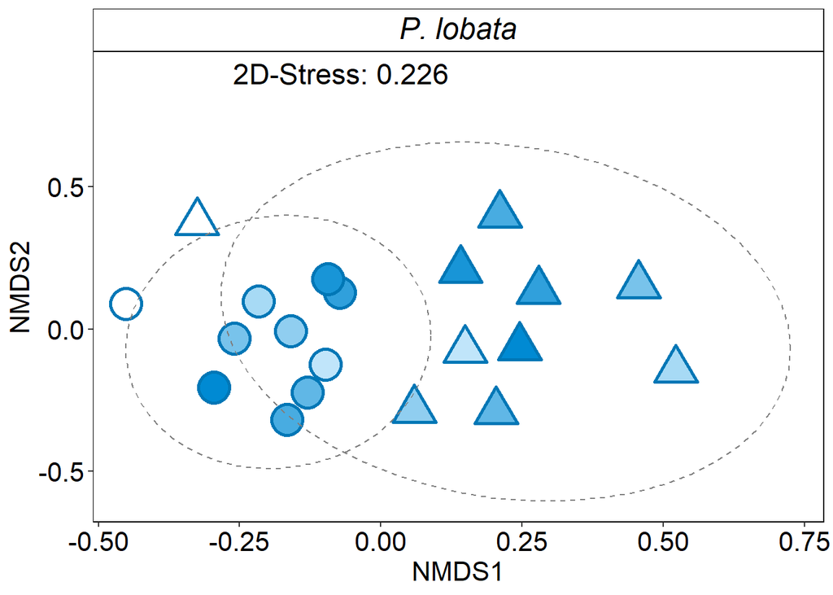

```r
#Extract the data
Porites_ord_data <- as.data.frame(scores(Porites_ord)$sites) %>%
  #Include sample names
  rownames_to_column(var = "Sample_name") %>%
  #Include the Location, Species and DNA_Method
  mutate(Coral_genus = factor(x = case_when(grepl(pattern = "^P", x = Sample_name, ignore.case = T) ~ "Porites",
                           grepl(pattern = "^D", x = Sample_name, ignore.case = T) ~ "Diploastrea"), levels = c("Porites", "Diploastrea")),

         Coral_genus_2 = factor(x = case_when(grepl(pattern = "^P", x = Sample_name, ignore.case = T) ~ "Porites",
                           grepl(pattern = "^D", x = Sample_name, ignore.case = T) ~ "Diploastrea"), levels = c("Porites", "Diploastrea"), labels = c("*P. lobata*", "*D. heliopora*")),

         Coral_genus_fill_aes = factor(x = case_when(grepl(pattern = "^P", x = Sample_name, ignore.case = T) ~ "Porites",
                           grepl(pattern = "^D", x = Sample_name, ignore.case = T) ~ "Diploastrea"), levels = c("Porites", "Diploastrea"), labels = c(21, 24)),


         #DNA extraction method
         DNA_method = factor(x = case_when(grepl(pattern = "B$", x = Sample_name, ignore.case = T) ~ "PowerSoil_EDTA",
                              grepl(pattern = "D$", x = Sample_name, ignore.case = T) ~ "PowerSoil",
                              grepl(pattern = "E$", x = Sample_name, ignore.case = T) ~ "PowerSoil_EDTA",
                              grepl(pattern = "F$", x = Sample_name, ignore.case = T) ~ "Ancient_DNA"), levels = c("PowerSoil", "PowerSoil_EDTA", "Ancient_DNA")),


         #Sampling location
         Location = factor(x = case_when(grepl(pattern = "B$", x = Sample_name, ignore.case = T) ~ "Palau",
                              grepl(pattern = "D$", x = Sample_name, ignore.case = T) ~ "PNG",
                              grepl(pattern = "E$", x = Sample_name, ignore.case = T) ~ "PNG",
                              grepl(pattern = "F$", x = Sample_name, ignore.case = T) ~ "PNG"), levels = c("Palau", "PNG")),


         Location_shape_aes = factor(x = case_when(grepl(pattern = "B$", x = Sample_name, ignore.case = T) ~ "Palau",
                              grepl(pattern = "D$", x = Sample_name, ignore.case = T) ~ "PNG",
                              grepl(pattern = "E$", x = Sample_name, ignore.case = T) ~ "PNG",
                              grepl(pattern = "F$", x = Sample_name, ignore.case = T) ~ "PNG"), levels = c("Palau", "PNG"), labels = c(21,24)),


         #Number asociated with each fragment
         Fragment_label = factor(x = case_when(grepl(pattern = "^[PD]0", x = Sample_name, ignore.case = T) ~ "Head",
                                           grepl(pattern = "^[PD]1[^678]", x = Sample_name, ignore.case = T) ~ "1",
                                           grepl(pattern = "^[PD]2[^012]", x = Sample_name, ignore.case = T) ~ "2",
                                           grepl(pattern = "^[PD]3", x = Sample_name, ignore.case = T) ~ "3",
                                           grepl(pattern = "^[PD]4", x = Sample_name, ignore.case = T) ~ "4",
                                           grepl(pattern = "^[PD]5", x = Sample_name, ignore.case = T) ~ "5",
                                           grepl(pattern = "^[PD]6", x = Sample_name, ignore.case = T) ~ "6",
                                           grepl(pattern = "P16", x = Sample_name, ignore.case = T) ~ "Anc1",
                                           grepl(pattern = "P17", x = Sample_name, ignore.case = T) ~ "Anc2",
                                           grepl(pattern = "P18", x = Sample_name, ignore.case = T) ~ "Anc3",
                                           grepl(pattern = "D20", x = Sample_name, ignore.case = T) ~ "Anc1",
                                           grepl(pattern = "D21", x = Sample_name, ignore.case = T) ~ "Anc2",
                                           grepl(pattern = "D22", x = Sample_name, ignore.case = T) ~ "Anc3"), levels = c("Head", "1", "2", "3", "4", "5", "6", "Anc1", "Anc2", "Anc3")),

         #Fragment age
         Fragment_age = factor(x = case_when(grepl(pattern = "^[PD]0", x = Sample_name, ignore.case = T) ~ "0",
                                           grepl(pattern = "^[PD]1[^678]", x = Sample_name, ignore.case = T) ~ "5",
                                           grepl(pattern = "^[PD]2[^012]", x = Sample_name, ignore.case = T) ~ "10",
                                           grepl(pattern = "^[PD]3", x = Sample_name, ignore.case = T) ~ "15",
                                           grepl(pattern = "^[PD]4", x = Sample_name, ignore.case = T) ~ "20",
                                           grepl(pattern = "^[PD]5", x = Sample_name, ignore.case = T) ~ "25",
                                           grepl(pattern = "^[PD]6", x = Sample_name, ignore.case = T) ~ "30",
                                           grepl(pattern = "P16", x = Sample_name, ignore.case = T) ~ "80",
                                           grepl(pattern = "P17", x = Sample_name, ignore.case = T) ~ "85",
                                           grepl(pattern = "P18", x = Sample_name, ignore.case = T) ~ "90",
                                           grepl(pattern = "D20", x = Sample_name, ignore.case = T) ~ "100",
                                           grepl(pattern = "D21", x = Sample_name, ignore.case = T) ~ "105",
                                           grepl(pattern = "D22", x = Sample_name, ignore.case = T) ~ "110"), levels = c("0", "5", "10", "15", "20", "25", "30", "80", "85", "90", "100", "105", "110")) )

#_____________________________________

#Plot the nMDS

Porites_ord_plot <- left_join(Porites_ord_data, Location_species_ord_all_data_colors, by = c("Coral_genus", "Fragment_age")) %>%
  #Select the data for plotting
  ggplot(aes(x = NMDS1, y = NMDS2)) +
  #Select the type of plot
  geom_point(aes(fill = Coral_genus_Frag_age, shape = Location, color = Coral_genus), size = 8, show.legend = F, stroke = 1.5) +
  #Include the shape selection
  scale_shape_manual(values = c(21, 24)) +
  #Include the elipses
  stat_ellipse(aes(color = Location), linetype = "dashed", show.legend = F,
               #color = c("#0077b6", "#780000")
               ) +
  #Include the color selection
  scale_fill_manual(values = setNames(
    left_join(Porites_ord_data, Location_species_ord_all_data_colors, by = c("Coral_genus", "Fragment_age"))$Fragment_age_color,
    left_join(Porites_ord_data, Location_species_ord_all_data_colors, by = c("Coral_genus", "Fragment_age"))$Coral_genus_Frag_age)) +
  #Include the color selection
  scale_color_manual(values = setNames(
    left_join(Porites_ord_data, Location_species_ord_all_data_colors, by = c("Coral_genus", "Fragment_age"))$Coral_genus_color,
    left_join(Porites_ord_data, Location_species_ord_all_data_colors, by = c("Coral_genus", "Fragment_age"))$Coral_genus)) +
  #Include facet for the title
  facet_grid(cols = vars(Coral_genus_2)) +
    #Include the Stress inside the plot
  annotate(geom = "text", x = -0.07, y = 0.9, label = paste("2D-Stress:", signif(Porites_ord$stress, 3)), size = 6) +
  #Include the Stress value
  labs(
    #subtitle = paste("2D-Stress:", signif(Porites_ord$stress, 3))
    ) +
  #Modify the theme
  theme(panel.grid = element_blank(),
      panel.background = element_rect(fill = "white",  color = "black"),
      #Modify the caption size
      plot.subtitle = element_text(size = 16),
      #Modify the axis text
      axis.text = element_text(size = 16, color = "black"),
      axis.title = element_text(size = 16, color = "black"),
      #Modify the legend elements
      legend.position = "bottom",
      legend.key = element_rect(fill = "white", color = "white"),
      legend.title = element_text(color = "black", size = 16, hjust = 0.5), #Before size = 12
      legend.text = element_text(color = "black", size = 16), #Before size = 12
      #Change the color of the facet label
      strip.background = element_rect(fill = "white", color = "black"),
      #Increase facet label text size
      strip.text = ggtext::element_markdown(color = "black", size = 18)
      )

Porites_ord_plot
```

```r
#________________________________________________________________________________________

#Diplo

#Create the datasets

#Ordination
##Set the random seed
set.seed(15081998)
Diplo_ord <- metaMDS(comm = Abundance %>% filter(Coral_genus == "Diploastrea" & DNA_method == "PowerSoil_EDTA" & Rel_abund_per > 0.1) %>% pivot_wider(id_cols = Sample_name, names_from = Symbiont_genus, values_from = Abundance, values_fill = 0) %>% column_to_rownames(var = "Sample_name"), dist = "bray")
```

```
## Square root transformation
## Wisconsin double standardization
## *** Best solution repeated 3 times
```

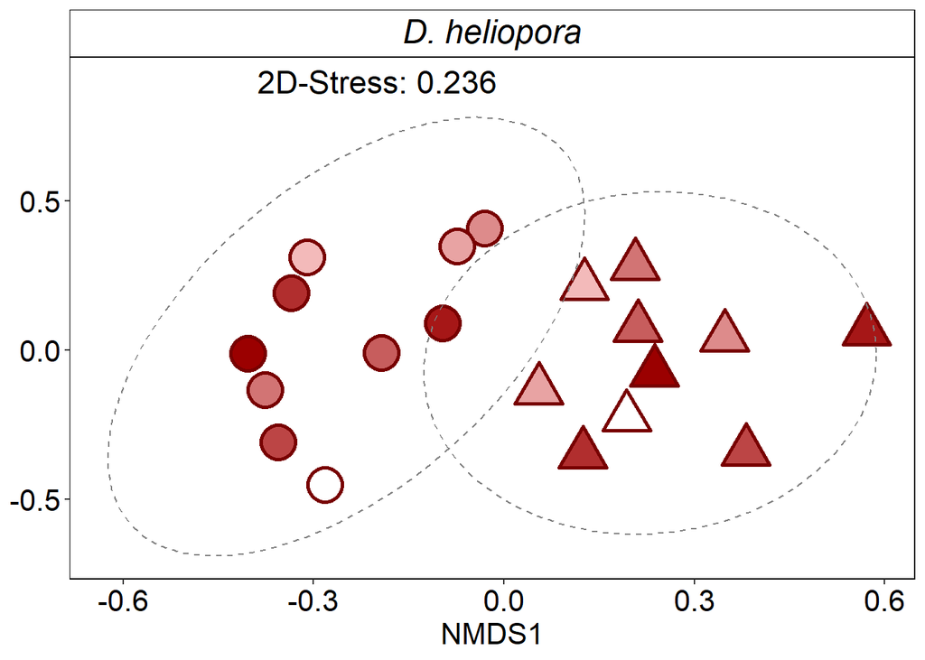

```r
#Extract the data
Diplo_ord_data <- as.data.frame(scores(Diplo_ord)$sites) %>%
  #Include sample names
  rownames_to_column(var = "Sample_name") %>%
  #Include the Location, Species and DNA_Method
  mutate(Coral_genus = factor(x = case_when(grepl(pattern = "^P", x = Sample_name, ignore.case = T) ~ "Porites",
                           grepl(pattern = "^D", x = Sample_name, ignore.case = T) ~ "Diploastrea"), levels = c("Porites", "Diploastrea")),

         Coral_genus_2 = factor(x = case_when(grepl(pattern = "^P", x = Sample_name, ignore.case = T) ~ "Porites",
                           grepl(pattern = "^D", x = Sample_name, ignore.case = T) ~ "Diploastrea"), levels = c("Porites", "Diploastrea"), labels = c("*P. lobata*", "*D. heliopora*")),

         Coral_genus_fill_aes = factor(x = case_when(grepl(pattern = "^P", x = Sample_name, ignore.case = T) ~ "Porites",
                           grepl(pattern = "^D", x = Sample_name, ignore.case = T) ~ "Diploastrea"), levels = c("Porites", "Diploastrea"), labels = c(21, 24)),


         #DNA extraction method
         DNA_method = factor(x = case_when(grepl(pattern = "B$", x = Sample_name, ignore.case = T) ~ "PowerSoil_EDTA",
                              grepl(pattern = "D$", x = Sample_name, ignore.case = T) ~ "PowerSoil",
                              grepl(pattern = "E$", x = Sample_name, ignore.case = T) ~ "PowerSoil_EDTA",
                              grepl(pattern = "F$", x = Sample_name, ignore.case = T) ~ "Ancient_DNA"), levels = c("PowerSoil", "PowerSoil_EDTA", "Ancient_DNA")),


         #Sampling location
         Location = factor(x = case_when(grepl(pattern = "B$", x = Sample_name, ignore.case = T) ~ "Palau",
                              grepl(pattern = "D$", x = Sample_name, ignore.case = T) ~ "PNG",
                              grepl(pattern = "E$", x = Sample_name, ignore.case = T) ~ "PNG",
                              grepl(pattern = "F$", x = Sample_name, ignore.case = T) ~ "PNG"), levels = c("Palau", "PNG")),


         Location_shape_aes = factor(x = case_when(grepl(pattern = "B$", x = Sample_name, ignore.case = T) ~ "Palau",
                              grepl(pattern = "D$", x = Sample_name, ignore.case = T) ~ "PNG",
                              grepl(pattern = "E$", x = Sample_name, ignore.case = T) ~ "PNG",
                              grepl(pattern = "F$", x = Sample_name, ignore.case = T) ~ "PNG"), levels = c("Palau", "PNG"), labels = c(21,24)),


         #Number asociated with each fragment
         Fragment_label = factor(x = case_when(grepl(pattern = "^[PD]0", x = Sample_name, ignore.case = T) ~ "Head",
                                           grepl(pattern = "^[PD]1[^678]", x = Sample_name, ignore.case = T) ~ "1",
                                           grepl(pattern = "^[PD]2[^012]", x = Sample_name, ignore.case = T) ~ "2",
                                           grepl(pattern = "^[PD]3", x = Sample_name, ignore.case = T) ~ "3",
                                           grepl(pattern = "^[PD]4", x = Sample_name, ignore.case = T) ~ "4",
                                           grepl(pattern = "^[PD]5", x = Sample_name, ignore.case = T) ~ "5",
                                           grepl(pattern = "^[PD]6", x = Sample_name, ignore.case = T) ~ "6",
                                           grepl(pattern = "P16", x = Sample_name, ignore.case = T) ~ "Anc1",
                                           grepl(pattern = "P17", x = Sample_name, ignore.case = T) ~ "Anc2",
                                           grepl(pattern = "P18", x = Sample_name, ignore.case = T) ~ "Anc3",
                                           grepl(pattern = "D20", x = Sample_name, ignore.case = T) ~ "Anc1",
                                           grepl(pattern = "D21", x = Sample_name, ignore.case = T) ~ "Anc2",
                                           grepl(pattern = "D22", x = Sample_name, ignore.case = T) ~ "Anc3"), levels = c("Head", "1", "2", "3", "4", "5", "6", "Anc1", "Anc2", "Anc3")),

         #Fragment age
         Fragment_age = factor(x = case_when(grepl(pattern = "^[PD]0", x = Sample_name, ignore.case = T) ~ "0",
                                           grepl(pattern = "^[PD]1[^678]", x = Sample_name, ignore.case = T) ~ "5",
                                           grepl(pattern = "^[PD]2[^012]", x = Sample_name, ignore.case = T) ~ "10",
                                           grepl(pattern = "^[PD]3", x = Sample_name, ignore.case = T) ~ "15",
                                           grepl(pattern = "^[PD]4", x = Sample_name, ignore.case = T) ~ "20",
                                           grepl(pattern = "^[PD]5", x = Sample_name, ignore.case = T) ~ "25",
                                           grepl(pattern = "^[PD]6", x = Sample_name, ignore.case = T) ~ "30",
                                           grepl(pattern = "P16", x = Sample_name, ignore.case = T) ~ "80",
                                           grepl(pattern = "P17", x = Sample_name, ignore.case = T) ~ "85",
                                           grepl(pattern = "P18", x = Sample_name, ignore.case = T) ~ "90",
                                           grepl(pattern = "D20", x = Sample_name, ignore.case = T) ~ "100",
                                           grepl(pattern = "D21", x = Sample_name, ignore.case = T) ~ "105",
                                           grepl(pattern = "D22", x = Sample_name, ignore.case = T) ~ "110"), levels = c("0", "5", "10", "15", "20", "25", "30", "80", "85", "90", "100", "105", "110")) )

#_____________________________________

#Plot the nMDS

Diplo_ord_plot <- left_join(Diplo_ord_data, Location_species_ord_all_data_colors, by = c("Coral_genus", "Fragment_age")) %>%
  #Select the data for plotting
  ggplot(aes(x = NMDS1, y = NMDS2)) +
  #Select the type of plot
  geom_point(aes(fill = Coral_genus_Frag_age, shape = Location, color = Coral_genus), size = 8, show.legend = F, stroke = 1.5) +
  #Include the shape selection
  scale_shape_manual(values = c(21, 24)) +
  #Include the elipses
  stat_ellipse(aes(color = Location), linetype = "dashed", show.legend = F,
               #color = c("#0077b6", "#780000")
               ) +
  #Include the color selection
  scale_fill_manual(values = setNames(
    left_join(Diplo_ord_data, Location_species_ord_all_data_colors, by = c("Coral_genus", "Fragment_age"))$Fragment_age_color,
    left_join(Diplo_ord_data, Location_species_ord_all_data_colors, by = c("Coral_genus", "Fragment_age"))$Coral_genus_Frag_age)) +
  #Include the color selection
  scale_color_manual(values = setNames(
    left_join(Diplo_ord_data, Location_species_ord_all_data_colors, by = c("Coral_genus", "Fragment_age"))$Coral_genus_color,
    left_join(Diplo_ord_data, Location_species_ord_all_data_colors, by = c("Coral_genus", "Fragment_age"))$Coral_genus)) +
  #Include facet for the title
  facet_grid(cols = vars(Coral_genus_2)) +
  #Include the Stress inside the plot
  annotate(geom = "text", x = -0.2, y = 0.9, label = paste("2D-Stress:", signif(Diplo_ord$stress, 3)), size = 6) +
  #Include the Stress value
  labs(y = NULL
    #subtitle = paste("2D-Stress:", signif(Diplo_ord$stress, 3))
    ) +
  #Modify the theme
  theme(panel.grid = element_blank(),
      panel.background = element_rect(fill = "white",  color = "black"),
      #Modify the caption size
      plot.subtitle = element_text(size = 16),
      #Modify the axis text
      axis.text = element_text(size = 16, color = "black"),
      axis.title = element_text(size = 16, color = "black"),
      #Modify the legend elements
      legend.position = "bottom",
      legend.key = element_rect(fill = "white", color = "white"),
      legend.title = element_text(color = "black", size = 16, hjust = 0.5), #Before size = 12
      legend.text = element_text(color = "black", size = 16), #Before size = 12
      #Change the color of the facet label
      strip.background = element_rect(fill = "white", color = "black"),
      #Increase facet label text size
      strip.text = ggtext::element_markdown(color = "black", size = 18)
      )

Diplo_ord_plot
```

```r
NMDS_mock_data <- data.frame(Coral_genus = factor(x = c(rep(x = "Porites", times = 10), rep(x = "Diploastrea", times = 10)), levels = c("Porites", "Diploastrea")),

                             Coral_genus_color = c(rep(x = "#0077b6", 10), rep(x = "#780000", 10)),

                             Fragment_age = factor(x = rep(x = c(as.character(seq(from = 0, to = 30, by = 5)), "Anc1", "Anc2", "Anc3"), 2), levels = c(as.character(seq(from = 0, to = 30, by = 5)), "Anc1", "Anc2", "Anc3")),

                             Fragment_age_color = c("#FFFFFF", "#DCDCDC", "#CECECE", "#BFBFBF", "#B1B1B1", "#A2A2A2", "#949494", "#858585", "#777777", "#696969"))

#____________________________________________________________________________________

#Long format legends

#Create legend for Coral_genus
##Plot the data
NMDS_mock_data_Coral_genus <- NMDS_mock_data %>%
  #Select the data for plotting
  ggplot(aes(Coral_genus, Fragment_age)) +
  #Select the type of plot
  geom_point(aes(fill = Coral_genus), shape = 21, size = 10, stroke = 1.5) +
  #Set the color scale
  scale_fill_manual(values = c("Porites" = "#0077b6", "Diploastrea" = "#780000"), labels = c("*Porites<br>lobata*", "*Diploastrea<br>heliopora*")) +
  #Modify the theme
  theme(#Modify the legend elements
        legend.position = "bottom",
        legend.key = element_rect(fill = "white", color = "white"),
        legend.title = element_text(color = "black", size = 16, hjust = 0.5), #Before size = 12
        legend.text = ggtext::element_markdown(color = "black", size = 16) #Before size = 12
        )



NMDS_mock_data_Shape <- NMDS_mock_data %>%
  #Select the data for plotting
  ggplot(aes(Coral_genus, Fragment_age)) +
  #Select the type of plot
  geom_point(aes(shape = Coral_genus), size = 10, stroke = 1.5) +
  #Set the color scale
  scale_shape_manual(values = c("Porites" = 21, "Diploastrea" = 24), labels = c("Palau", "Papua New Guinea"), name = "Sampling\nLocation") +
  #Modify the theme
  theme(#Modify the legend elements
        legend.position = "bottom",
        legend.key = element_rect(fill = "white", color = "white"),
        legend.title = element_text(color = "black", size = 16, hjust = 0.5), #Before size = 12
        legend.text = ggtext::element_markdown(color = "black", size = 16) #Before size = 12
        )


NMDS_mock_data_Fragment_age <- NMDS_mock_data %>%
  #Select the data for plotting
  ggplot(aes(Coral_genus, Fragment_age)) +
  #Select the type of plot
  geom_point(aes(fill = Fragment_age), shape = 21, size = 10, stroke = 1.5) +
  #Set the color scale
  scale_fill_manual(values = setNames(NMDS_mock_data$Fragment_age_color, NMDS_mock_data$Fragment_age), name = "Fragment\nage") +
  #Create legend for Fragment_age
  guides(fill = guide_legend(nrow = 1,
                             theme = theme(legend.byrow = T))) +
  #Modify the theme
  theme(#Modify the legend elements
        legend.position = "bottom",
        legend.key = element_rect(fill = "white", color = "white"),
        legend.text.position = "bottom",
        legend.title = element_text(color = "black", size = 16, hjust = 0.5), #Before size = 12
        legend.text = ggtext::element_markdown(color = "black", size = 16) #Before size = 12
        )
```

[figure not shown]

```r
#Define the layout
NMDS_species_location_plot_layout <- "
AABC
AADE
FFGG
HHHH"

#Extract the legend for shape
Location_species_ord_all_plot_legend_shape  <- ggpubr::as_ggplot(ggpubr::get_legend(NMDS_mock_data_Shape))

#Extract the legend for Coral_genus
Location_species_ord_all_plot_legend_genus <- ggpubr::as_ggplot(ggpubr::get_legend(NMDS_mock_data_Coral_genus))

#Extract the legend for Location
Location_species_ord_all_plot_legend_frag_age <- ggpubr::as_ggplot(ggpubr::get_legend(NMDS_mock_data_Fragment_age))


Figure_3 <- Location_species_ord_all_plot + Palau_ord_plot + PNG_ord_plot + Porites_ord_plot + Diplo_ord_plot + Location_species_ord_all_plot_legend_shape + Location_species_ord_all_plot_legend_genus + Location_species_ord_all_plot_legend_frag_age +
  #Include the design
  plot_layout(design = NMDS_species_location_plot_layout, heights = c(1, 1, 0.2, 0.2)) +
  #Include tags
  plot_annotation(tag_levels = list(c("(a)", "(b)", "(c)", "(d)", "(e)", "", "", ""))) & theme(plot.tag = element_text(size = 20, face = "bold"), legend.position = "none", plot.tag.position = c(0.05, 1) )

Figure_3
```

```r
#ggsave(filename = "Figures/Figure_3.svg", width = 370, height = 250, units = "mm", dpi = 1800)
#ggsave(filename = "Figures/Figure_3.pdf", width = 370, height = 250, units = "mm", dpi = 1800)
#ggsave(filename = "Figures/Figure_3.png", width = 370, height = 250, units = "mm", dpi = 1000)
```

### PERMANOVA

We will perform a PERMANOVA and test the assumptions to figure out if there are significantly different or not.

```r
#Create the datasets
##Distance matrix
Location_species_dist <- vegdist(x = Abundance %>%
  #Obtain only Porites for PNG over 0.1%
  filter(DNA_method == "PowerSoil_EDTA" & Rel_abund_per > 0.1) %>%
  #Change the data structure: Rows are samples, columns are Post-MED sequences or Coral_genus DIV
  pivot_wider(id_cols = Sample_name, names_from = Symbiont_genus, values_from = Abundance, values_fill = 0) %>%
  #Assign sample names as row names for the vegdist function
  column_to_rownames(var = "Sample_name"),
  method = "bray")

##Metadata for distance matrix
Location_species_dist_metadata <- Abundance %>%
  #Obtain only Porites for PNG over 0.1%
  filter(DNA_method == "PowerSoil_EDTA" & Rel_abund_per > 0.1) %>%
  #Change the data structure: Rows are samples, columns are Post-MED sequences or Coral_genus DIV
  pivot_wider(id_cols = Sample_name, names_from = Symbiont_genus, values_from = Abundance, values_fill = 0) %>%
  #Create a new metadata column with the DNA_methods
  mutate(Coral_genus = factor(x = case_when(
                           grepl(pattern = "^P", x = Sample_name, ignore.case = T) ~ "Porites",
                           grepl(pattern = "^D", x = Sample_name, ignore.case = T) ~ "Diploastrea"), levels = c("Porites", "Diploastrea")),

         #Sampling location
         Location = factor(x = case_when(grepl(pattern = "B$", x = Sample_name, ignore.case = T) ~ "Palau",
                              grepl(pattern = "D$", x = Sample_name, ignore.case = T) ~ "PNG",
                              grepl(pattern = "E$", x = Sample_name, ignore.case = T) ~ "PNG",
                              grepl(pattern = "F$", x = Sample_name, ignore.case = T) ~ "PNG"), levels = c("Palau", "PNG")),

         Fragment_label = factor(x = case_when(grepl(pattern = "^[PD]0", x = Sample_name, ignore.case = T) ~ "Head",
                                           grepl(pattern = "^[PD]1[^678]", x = Sample_name, ignore.case = T) ~ "1",
                                           grepl(pattern = "^[PD]2[^012]", x = Sample_name, ignore.case = T) ~ "2",
                                           grepl(pattern = "^[PD]3", x = Sample_name, ignore.case = T) ~ "3",
                                           grepl(pattern = "^[PD]4", x = Sample_name, ignore.case = T) ~ "4",
                                           grepl(pattern = "^[PD]5", x = Sample_name, ignore.case = T) ~ "5",
                                           grepl(pattern = "^[PD]6", x = Sample_name, ignore.case = T) ~ "6",
                                           grepl(pattern = "P16", x = Sample_name, ignore.case = T) ~ "Anc1",
                                           grepl(pattern = "P17", x = Sample_name, ignore.case = T) ~ "Anc2",
                                           grepl(pattern = "P18", x = Sample_name, ignore.case = T) ~ "Anc3",
                                            grepl(pattern = "D20", x = Sample_name, ignore.case = T) ~ "Anc1",
                                           grepl(pattern = "D21", x = Sample_name, ignore.case = T) ~ "Anc2",
                                           grepl(pattern = "D22", x = Sample_name, ignore.case = T) ~ "Anc3"), levels = c("Head", "1", "2", "3", "4", "5", "6", "Anc1", "Anc2", "Anc3"))) %>%
  #Assign sample names as row names for the adonis function
  column_to_rownames(var = "Sample_name")

#_____________________________________________________________________________

#Run the PERMANOVA

#Set the random seed
set.seed(15081998)
#Run the PERMANOVA - Only for DNA methods
adonis2(formula = Location_species_dist ~ Location * Coral_genus, data = Location_species_dist_metadata, permutations = 9999, by = "terms")
```

```
## Permutation test for adonis under reduced model
## Terms added sequentially (first to last)
## Permutation: free
## Number of permutations: 9999
##
## adonis2(formula = Location_species_dist ~ Location * Coral_genus, data = Location_species_dist_metadata, permutations = 9999, by = "terms")
##                      Df SumOfSqs      R2      F Pr(>F)
## Location              1   0.6966 0.04074 1.6932  1e-04 ***
## Coral_genus           1   0.6720 0.03931 1.6334  4e-04 ***
## Location:Coral_genus  1   0.9176 0.05367 2.2304  1e-04 ***
## Residual             36  14.8110 0.86628
## Total                39  17.0973 1.00000
## ---
## Signif. codes:  0 '***' 0.001 '**' 0.01 '*' 0.05 '.' 0.1 ' ' 1
```

```r
#________________________________________________________________________________________________

#Test for multivariate homogeneity of variances
##Betadisper - general
anova(betadisper(Location_species_dist, group = with(Location_species_dist_metadata, interaction(Location, Coral_genus)) ))
```

```
## Analysis of Variance Table
##
## Response: Distances
##           Df   Sum Sq   Mean Sq F value Pr(>F)
## Groups     3 0.017299 0.0057662  3.9191 0.0161 *
## Residuals 36 0.052966 0.0014713
## ---
## Signif. codes:  0 '***' 0.001 '**' 0.01 '*' 0.05 '.' 0.1 ' ' 1
```

```r
##Betadisper based on permutations
set.seed(15081998)
permutest(betadisper(Location_species_dist, group = with(Location_species_dist_metadata, interaction(Location, Coral_genus)) ))
```

```
##
## Permutation test for homogeneity of multivariate dispersions
## Permutation: free
## Number of permutations: 999
##
## Response: Distances
##           Df   Sum Sq   Mean Sq      F N.Perm Pr(>F)
## Groups     3 0.017299 0.0057662 3.9191    999  0.011 *
## Residuals 36 0.052966 0.0014713
## ---
## Signif. codes:  0 '***' 0.001 '**' 0.01 '*' 0.05 '.' 0.1 ' ' 1
```

```r
##Pairwise betadisper
TukeyHSD(betadisper(Location_species_dist, group = with(Location_species_dist_metadata, interaction(Location, Coral_genus)) ))
```

```
##   Tukey multiple comparisons of means
##     95% family-wise confidence level
##
## Fit: aov(formula = distances ~ group, data = df)
##
## $group
##                                          diff          lwr        upr     p adj
## PNG.Porites-Palau.Porites          0.05599530  0.009795932 0.10219467 0.0123234
## Palau.Diploastrea-Palau.Porites    0.04359001 -0.002609359 0.08978938 0.0703374
## PNG.Diploastrea-Palau.Porites      0.03340557 -0.012793797 0.07960494 0.2269010
## Palau.Diploastrea-PNG.Porites     -0.01240529 -0.058604662 0.03379408 0.8871982
## PNG.Diploastrea-PNG.Porites       -0.02258973 -0.068789100 0.02360964 0.5584759
## PNG.Diploastrea-Palau.Diploastrea -0.01018444 -0.056383809 0.03601493 0.9333287
```

```r
#________________________________________________________________________________________________

#Posthoc PERMANOVA
set.seed(15081998)
pairwise.adonis(x = Location_species_dist, factors = with(Location_species_dist_metadata, interaction(Location, Coral_genus)))
```

```
##                                  pairs Df SumsOfSqs  F.Model         R2 p.value
## 1   Palau.Porites vs Palau.Diploastrea  1 0.9643919 2.431759 0.11901858   0.001
## 2         Palau.Porites vs PNG.Porites  1 0.8795676 2.169009 0.10754168   0.002
## 3     Palau.Porites vs PNG.Diploastrea  1 0.7920668 2.032314 0.10145178   0.001
## 4     Palau.Diploastrea vs PNG.Porites  1 0.5765544 1.331229 0.06886416   0.003
## 5 Palau.Diploastrea vs PNG.Diploastrea  1 0.7346676 1.760442 0.08908921   0.001
## 6       PNG.Porites vs PNG.Diploastrea  1 0.6252636 1.466881 0.07535266   0.001
##   p.adjusted sig
## 1      0.006   *
## 2      0.012   .
## 3      0.006   *
## 4      0.018   .
## 5      0.006   *
## 6      0.006   *
```

### Distance-Decay plot

```r
#Community

#Create the dataset
Palau_Porites_decade <- Abundance %>%
  #Filter to obtain Porites from Palau
  filter(Location == "Palau", Coral_genus == "Porites" & DNA_method == "PowerSoil_EDTA" & Rel_abund_per > 0.1) %>%
  #Filter to obtain only recent samples
  filter(!grepl(pattern = "Anc", x = Fragment_label)) %>%
  #Change the data structure
  pivot_wider(id_cols = Sample_name, names_from = Symbiont_genus, values_from = Abundance, values_fill = 0) %>%
  #Remove sample names
  column_to_rownames(var = "Sample_name")

#Compute the distances
Palau_Porites_decade_dist <- as.vector(1 - vegdist(x = Palau_Porites_decade, method = "bray"))

#___________________________________________________________________________________

# Core distance

#Create the dataset
Palau_Porites_decade_core <- Abundance %>%
  #Filter to obtain Porites from Palau
  filter(Location == "Palau", Coral_genus == "Porites" & DNA_method == "PowerSoil_EDTA" & Rel_abund_per > 0.1) %>%
  #Filter to obtain only recent samples
  filter(!grepl(pattern = "Anc", x = Fragment_label)) %>%
  #Select only the unique core names and ages
  distinct(Sample_name, Fragment_age) %>%
  #Remove sample names
  column_to_rownames(var = "Sample_name") %>%
  #Change to numeric variable
  mutate(Fragment_age = as.numeric(as.character(Fragment_age)))


#Compute the distances for the cores
Palau_Porites_decade_core_dist <- as.vector(vegdist(x = Palau_Porites_decade_core, method = "euclidean"))

#___________________________________________

#Create a dataframe
Palau_Porites_decade_dist_decay_data <- data.frame(Core_distance = Palau_Porites_decade_core_dist, Community_sim = Palau_Porites_decade_dist)


#Create the lineal model
Palau_Porites_decade_dist_decay_lm <- lm(formula = Community_sim ~ Core_distance, data = Palau_Porites_decade_dist_decay_data)
#Get summary of the lm model
Palau_Porites_decade_dist_decay_lm_sum <- summary(Palau_Porites_decade_dist_decay_lm)
#View the summary
Palau_Porites_decade_dist_decay_lm_sum
```

```
##
## Call:
## lm(formula = Community_sim ~ Core_distance, data = Palau_Porites_decade_dist_decay_data)
##
## Residuals:
##       Min        1Q    Median        3Q       Max
## -0.107403 -0.045420 -0.004848  0.047046  0.133287
##
## Coefficients:
##                Estimate Std. Error t value Pr(>|t|)
## (Intercept)    0.175890   0.028343   6.206 5.82e-06 ***
## Core_distance -0.003623   0.001856  -1.953   0.0658 .
## ---
## Signif. codes:  0 '***' 0.001 '**' 0.01 '*' 0.05 '.' 0.1 ' ' 1
##
## Residual standard error: 0.06338 on 19 degrees of freedom
## Multiple R-squared:  0.1671, Adjusted R-squared:  0.1233
## F-statistic: 3.812 on 1 and 19 DF,  p-value: 0.06577
```

```r
#Compute a Mantel test
##Pearson correlation
###Set the random seed
set.seed(15081998)
mantel(xdis = (1 - vegdist(x = Palau_Porites_decade, method = "bray")),
       ydis = vegdist(x = Palau_Porites_decade_core, method = "euclidean"),
       method = "pearson",
       permutations = 999)
```

```
## Set of permutations < 'minperm'. Generating entire set.
```

```
##
## Mantel statistic based on Pearson's product-moment correlation
##
## Call:
## mantel(xdis = (1 - vegdist(x = Palau_Porites_decade, method = "bray")),      ydis = vegdist(x = Palau_Porites_decade_core, method = "euclidean"),      method = "pearson", permutations = 999)
##
## Mantel statistic r: -0.4088
##       Significance: 0.961
##
## Upper quantiles of permutations (null model):
##   90%   95% 97.5%   99%
## 0.307 0.381 0.434 0.481
## Permutation: free
## Number of permutations: 5039
```

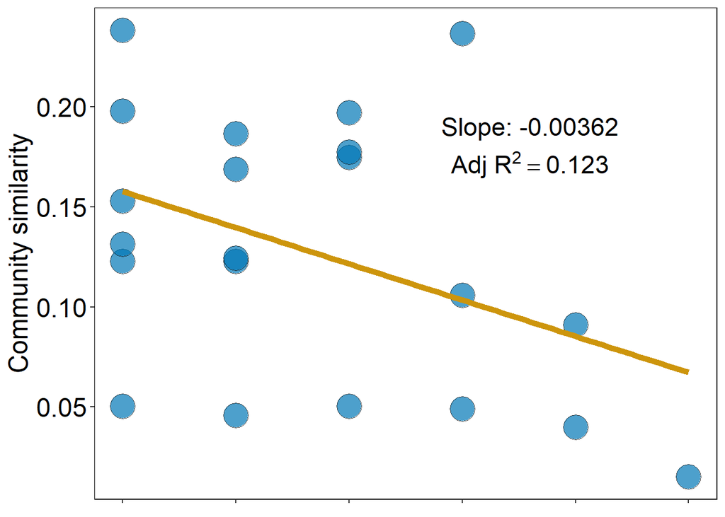

```r
#Plot the data
Palau_Porites_decade_dist_decay <- Palau_Porites_decade_dist_decay_data  %>%
  #Select the data
  ggplot(aes(x = Core_distance, y = Community_sim)) +
  #Select the type of plot
  geom_point(shape = 21, size = 8, fill = "#0077b6", alpha = 0.7) +
  #Include the regresion line
  geom_smooth(method = "lm", se = F, linewidth = 2, color = "darkgoldenrod3") +
  #Include the adj p-value and Adj R-squares
  annotate(geom = "text", x = 23, y = 0.18, label = paste0("atop('Slope: ", signif(Palau_Porites_decade_dist_decay_lm$coefficients["Core_distance"], 3), "', 'Adj R'^2=='", signif(Palau_Porites_decade_dist_decay_lm_sum$adj.r.squared, 3), "')"), size = 6, parse = T) +
  #Change the labels
  labs(x = NULL, y = "Community similarity") +
  #labs(x = "Time between Fragments (Years)", y = "Community similarity") +
  #Include x axis breaks
  scale_x_continuous(breaks = c(0, 5, 10, 15, 20, 25, 30)) +
  #Change the theme
  theme(panel.grid = element_blank(),
        panel.background = element_rect(fill = "white",  color = "black"),
        axis.text.x = element_text(size = 1, color = "white"),
        axis.text.y = element_text(size = 18, color = "black"),
        axis.title = element_text(size = 18, color = "black"),
        legend.position = "bottom",
        legend.key = element_rect(fill = "white", color = "white"),
        legend.title = element_text(color = "black", size = 12),
        legend.text = element_text(color = "black", size = 12))

Palau_Porites_decade_dist_decay
```

```r
#Community

#Create the dataset
Palau_Diplo_decade <- Abundance %>%
  #Filter to obtain Porites from Palau
  filter(Location == "Palau", Coral_genus == "Diploastrea" & Rel_abund_per > 0.1) %>%
  #Filter to obtain only recent samples
  filter(!grepl(pattern = "Anc", x = Fragment_label)) %>%
  #Change the data structure
  pivot_wider(id_cols = Sample_name, names_from = Symbiont_genus, values_from = Abundance, values_fill = 0) %>%
  #Remove sample names
  column_to_rownames(var = "Sample_name")

#Compute the distances
Palau_Diplo_decade_dist <- as.vector(1 - vegdist(x = Palau_Diplo_decade, method = "bray"))

#___________________________________________________________________________________

# Core distance

#Create the dataset
Palau_Diplo_decade_core <- Abundance %>%
  #Filter to obtain Porites from Palau
  filter(Location == "Palau", Coral_genus == "Diploastrea" & Rel_abund_per > 0.1) %>%
  #Filter to obtain only recent samples
  filter(!grepl(pattern = "Anc", x = Fragment_label)) %>%
  #Select only the unique core names and ages
  distinct(Sample_name, Fragment_age) %>%
  #Remove sample names
  column_to_rownames(var = "Sample_name") %>%
  #Change to numeric variable
  mutate(Fragment_age = as.numeric(as.character(Fragment_age)))


#Compute the distances for the cores
Palau_Diplo_decade_core_dist <- as.vector(vegdist(x = Palau_Diplo_decade_core, method = "euclidean"))

#___________________________________________

#Create a dataframe
Palau_Diplo_decade_dist_decay_data <- data.frame(Core_distance = Palau_Diplo_decade_core_dist, Community_sim = Palau_Diplo_decade_dist)


#Create the lineal model
Palau_Diplo_decade_dist_decay_lm <- lm(formula = Community_sim ~ Core_distance, data = Palau_Diplo_decade_dist_decay_data)
#Get summary of the lm model
Palau_Diplo_decade_dist_decay_lm_sum <- summary(Palau_Diplo_decade_dist_decay_lm)
#View the summary
Palau_Diplo_decade_dist_decay_lm_sum
```

```
##
## Call:
## lm(formula = Community_sim ~ Core_distance, data = Palau_Diplo_decade_dist_decay_data)
##
## Residuals:
##       Min        1Q    Median        3Q       Max
## -0.090482 -0.046737 -0.004678  0.022721  0.230784
##
## Coefficients:
##               Estimate Std. Error t value Pr(>|t|)
## (Intercept)   0.035847   0.035166   1.019    0.321
## Core_distance 0.003424   0.002302   1.487    0.153
##
## Residual standard error: 0.07863 on 19 degrees of freedom
## Multiple R-squared:  0.1043, Adjusted R-squared:  0.05713
## F-statistic: 2.212 on 1 and 19 DF,  p-value: 0.1534
```

```r
#Mantel test
###Set the random seed
set.seed(15081998)
mantel(xdis = (1 - vegdist(x = Palau_Diplo_decade, method = "bray")),
       ydis = vegdist(x = Palau_Diplo_decade_core, method = "euclidean"),
       method = "pearson",
       permutations = 999)
```

```
## Set of permutations < 'minperm'. Generating entire set.
```

```
##
## Mantel statistic based on Pearson's product-moment correlation
##
## Call:
## mantel(xdis = (1 - vegdist(x = Palau_Diplo_decade, method = "bray")),      ydis = vegdist(x = Palau_Diplo_decade_core, method = "euclidean"),      method = "pearson", permutations = 999)
##
## Mantel statistic r: 0.3229
##       Significance: 0.057
##
## Upper quantiles of permutations (null model):
##   90%   95% 97.5%   99%
## 0.284 0.329 0.357 0.372
## Permutation: free
## Number of permutations: 5039
```

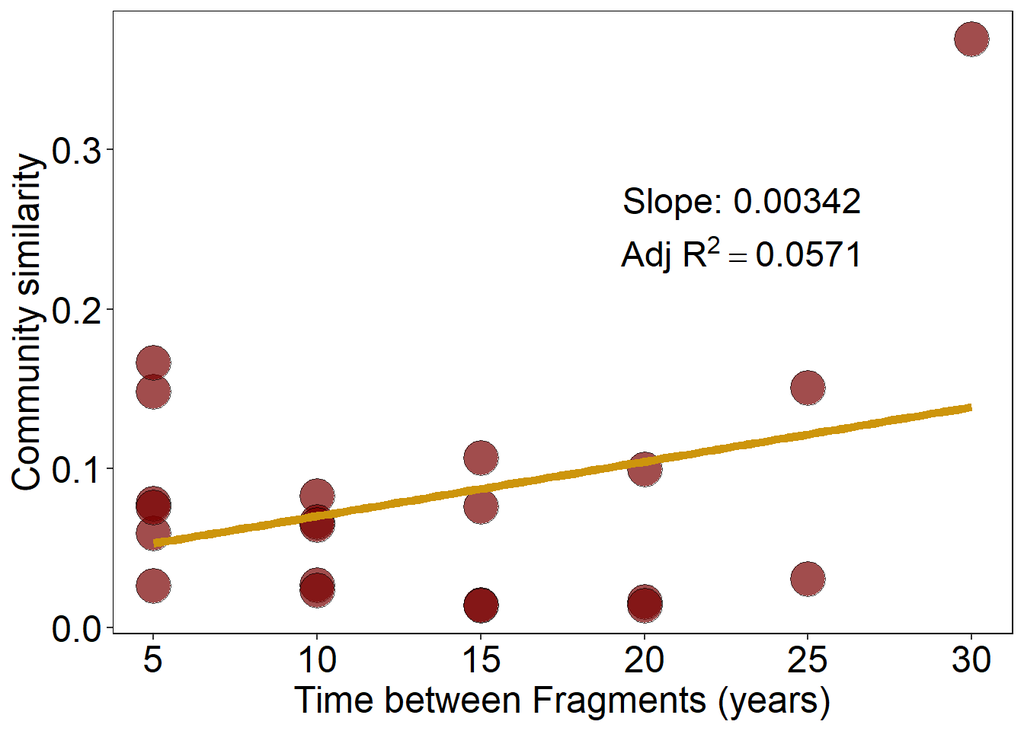

```r
#Plot the data
Palau_Diplo_decade_dist_decay <- Palau_Diplo_decade_dist_decay_data %>%
  #Select the data
  ggplot(aes(x = Core_distance, y = Community_sim)) +
  #Select the type of plot
  geom_point(shape = 21, size = 8, fill = "#780000", alpha = 0.7) +
  #Include the regresion line
  geom_smooth(method = "lm", se = F, linewidth = 2, color = "darkgoldenrod3") +
  #Include the adj p-value and Adj R-squares
  annotate(geom = "text", x = 23, y = 0.25, label = paste0("atop('Slope: ", signif(Palau_Diplo_decade_dist_decay_lm$coefficients["Core_distance"], 3), "', 'Adj R'^2=='", signif(Palau_Diplo_decade_dist_decay_lm_sum$adj.r.squared, 3), "')"), size = 6, parse = T) +
  #Change the labels
  labs(x = "Time between Fragments (years)", y = "Community similarity") +
  #Include x axis breaks
  scale_x_continuous(breaks = c(0, 5, 10, 15, 20, 25, 30)) +
  #Change the theme
  theme(panel.grid = element_blank(),
        panel.background = element_rect(fill = "white",  color = "black"),
        axis.text = element_text(size = 18, color = "black"),
        axis.title = element_text(size = 18, color = "black"),
        legend.position = "bottom",
        legend.key = element_rect(fill = "white", color = "white"),
        legend.title = element_text(color = "black", size = 12),
        legend.text = element_text(color = "black", size = 12))

Palau_Diplo_decade_dist_decay
```

```r
#Community

#Create the dataset
PNG_Porites_decade <- Abundance %>%
  #Filter to obtain Porites from PNG
  filter(Location == "PNG", Coral_genus == "Porites" & DNA_method == "PowerSoil_EDTA", Rel_abund_per > 0.1) %>%
  #Filter to obtain only recent samples
  filter(!grepl(pattern = "Anc", x = Fragment_label)) %>%
  #Change the data structure
  pivot_wider(id_cols = Sample_name, names_from = Symbiont_genus, values_from = Abundance, values_fill = 0) %>%
  #Remove sample names
  column_to_rownames(var = "Sample_name")

#Compute the distances
PNG_Porites_decade_dist <- as.vector(1 - vegdist(x = PNG_Porites_decade, method = "bray"))

#___________________________________________________________________________________

# Core distance

#Create the dataset
PNG_Porites_decade_core <- Abundance %>%
  #Filter to obtain Porites from PNG
  filter(Location == "PNG", Coral_genus == "Porites" & DNA_method == "PowerSoil_EDTA" & Rel_abund_per > 0.1) %>%
  #Filter to obtain only recent samples
  filter(!grepl(pattern = "Anc", x = Fragment_label)) %>%

  #Select only the unique core names and ages
  distinct(Sample_name, Fragment_age) %>%
  #Remove sample names
  column_to_rownames(var = "Sample_name") %>%
  #Change to numeric variable
  mutate(Fragment_age = as.numeric(as.character(Fragment_age)))


#Compute the distances for the cores
PNG_Porites_decade_core_dist <- as.vector(vegdist(x = PNG_Porites_decade_core, method = "euclidean"))

#___________________________________________

#Create a dataframe
PNG_Porites_decade_dist_decay_data <- data.frame(Core_distance = PNG_Porites_decade_core_dist, Community_sim = PNG_Porites_decade_dist)


#Create the lineal model
PNG_Porites_decade_dist_decay_lm <- lm(formula = Community_sim ~ Core_distance, data = PNG_Porites_decade_dist_decay_data)
#Get summary of the lm model
PNG_Porites_decade_dist_decay_lm_sum <- summary(PNG_Porites_decade_dist_decay_lm)
#View the summary
PNG_Porites_decade_dist_decay_lm_sum
```

```
##
## Call:
## lm(formula = Community_sim ~ Core_distance, data = PNG_Porites_decade_dist_decay_data)
##
## Residuals:
##      Min       1Q   Median       3Q      Max
## -0.04145 -0.01860 -0.00510  0.01100  0.08251
##
## Coefficients:
##                 Estimate Std. Error t value Pr(>|t|)
## (Intercept)    0.0487401  0.0134359   3.628  0.00179 **
## Core_distance -0.0003561  0.0008796  -0.405  0.69009
## ---
## Signif. codes:  0 '***' 0.001 '**' 0.01 '*' 0.05 '.' 0.1 ' ' 1
##
## Residual standard error: 0.03004 on 19 degrees of freedom
## Multiple R-squared:  0.008554,   Adjusted R-squared:  -0.04363
## F-statistic: 0.1639 on 1 and 19 DF,  p-value: 0.6901
```

```r
#Mantel test
###Set the random seed
set.seed(15081998)
mantel(xdis = (1 - vegdist(x = PNG_Porites_decade, method = "bray")),
       ydis = vegdist(x = PNG_Porites_decade_core, method = "euclidean"),
       method = "pearson",
       permutations = 999)
```

```
## Set of permutations < 'minperm'. Generating entire set.
```

```
##
## Mantel statistic based on Pearson's product-moment correlation
##
## Call:
## mantel(xdis = (1 - vegdist(x = PNG_Porites_decade, method = "bray")),      ydis = vegdist(x = PNG_Porites_decade_core, method = "euclidean"),      method = "pearson", permutations = 999)
##
## Mantel statistic r: -0.09249
##       Significance: 0.633
##
## Upper quantiles of permutations (null model):
##   90%   95% 97.5%   99%
## 0.310 0.391 0.447 0.516
## Permutation: free
## Number of permutations: 5039
```

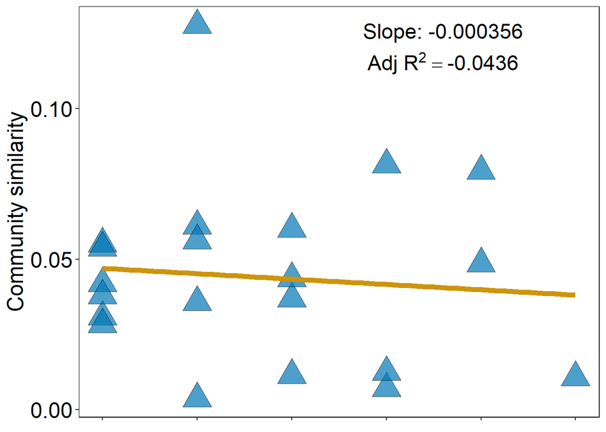

```r
#Plot the data
PNG_Porites_decade_dist_decay <- PNG_Porites_decade_dist_decay_data %>%
  #Select the data
  ggplot(aes(x = Core_distance, y = Community_sim)) +
  #Select the type of plot
  geom_point(shape = 24, size = 8, fill = "#0077b6", alpha = 0.7) +
  #Include the regresion line
  geom_smooth(method = "lm", se = F, linewidth = 2, color = "darkgoldenrod3") +
  #Include the adj p-value and Adj R-squares
  annotate(geom = "text", x = 23, y = 0.12, label = paste0("atop('Slope: ", signif(PNG_Porites_decade_dist_decay_lm$coefficients["Core_distance"], 3), "', 'Adj R'^2=='", signif(PNG_Porites_decade_dist_decay_lm_sum$adj.r.squared, 3), "')"), size = 6, parse = T) +
  #Include x axis breaks
  scale_x_continuous(breaks = c(0, 5, 10, 15, 20, 25, 30)) +
  #Change the labels
  labs(x = NULL, y = "Community similarity") +
  #labs(x = "Time between Fragments (Years)", y = "Community similarity") +
  #Change the theme
  theme(panel.grid = element_blank(),
        panel.background = element_rect(fill = "white",  color = "black"),
        axis.text.x = element_text(size = 1, color = "white"),
        axis.text.y = element_text(size = 18, color = "black"),
        axis.title = element_text(size = 18, color = "black"),
        legend.position = "bottom",
        legend.key = element_rect(fill = "white", color = "white"),
        legend.title = element_text(color = "black", size = 12),
        legend.text = element_text(color = "black", size = 12))

PNG_Porites_decade_dist_decay
```

```r
#Community

#Create the dataset
PNG_Diplo_decade <- Abundance %>%
  #Filter to obtain Porites from PNG
  filter(Location == "PNG", Coral_genus == "Diploastrea" & Rel_abund_per > 0.1) %>%
  #Filter to obtain only recent samples
  filter(!grepl(pattern = "Anc", x = Fragment_label)) %>%
  #Change the data structure
  pivot_wider(id_cols = Sample_name, names_from = Symbiont_genus, values_from = Abundance, values_fill = 0) %>%
  #Remove sample names
  column_to_rownames(var = "Sample_name")

#Compute the distances
PNG_Diplo_decade_dist <- as.vector(1 - vegdist(x = PNG_Diplo_decade, method = "bray"))

#___________________________________________________________________________________

# Core distance

#Create the dataset
PNG_Diplo_decade_core <- Abundance %>%
  #Filter to obtain Porites from PNG
  filter(Location == "PNG", Coral_genus == "Diploastrea" & Rel_abund_per > 0.1) %>%
  #Filter to obtain only recent samples
  filter(!grepl(pattern = "Anc", x = Fragment_label)) %>%
  #Select only the unique core names and ages
  distinct(Sample_name, Fragment_age) %>%
  #Remove sample names
  column_to_rownames(var = "Sample_name") %>%
  #Change to numeric variable
  mutate(Fragment_age = as.numeric(as.character(Fragment_age)))


#Compute the distances for the cores
PNG_Diplo_decade_core_dist <- as.vector(vegdist(x = PNG_Diplo_decade_core, method = "euclidean"))

#___________________________________________

#Create a dataframe
PNG_Diplo_decade_dist_decay_data <- data.frame(Core_distance = PNG_Diplo_decade_core_dist, Community_sim = PNG_Diplo_decade_dist)


#Create the lineal model
PNG_Diplo_decade_dist_decay_lm <- lm(formula = Community_sim ~ Core_distance, data = PNG_Diplo_decade_dist_decay_data)
#Get summary of the lm model
PNG_Diplo_decade_dist_decay_lm_sum <- summary(PNG_Diplo_decade_dist_decay_lm)
#View the summary
PNG_Diplo_decade_dist_decay_lm_sum
```

```
##
## Call:
## lm(formula = Community_sim ~ Core_distance, data = PNG_Diplo_decade_dist_decay_data)
##
## Residuals:
##       Min        1Q    Median        3Q       Max
## -0.069424 -0.021160  0.002243  0.016680  0.052788
##
## Coefficients:
##                 Estimate Std. Error t value Pr(>|t|)
## (Intercept)    0.1124294  0.0149337   7.529 4.08e-07 ***
## Core_distance -0.0006897  0.0009776  -0.705    0.489
## ---
## Signif. codes:  0 '***' 0.001 '**' 0.01 '*' 0.05 '.' 0.1 ' ' 1
##
## Residual standard error: 0.03339 on 19 degrees of freedom
## Multiple R-squared:  0.02553,    Adjusted R-squared:  -0.02576
## F-statistic: 0.4977 on 1 and 19 DF,  p-value: 0.4891
```

```r
#Mantel test
###Set the random seed
set.seed(15081998)
mantel(xdis = (1 - vegdist(x = PNG_Diplo_decade, method = "bray")),
       ydis = vegdist(x = PNG_Diplo_decade_core, method = "euclidean"),
       method = "pearson",
       permutations = 999)
```

```
## Set of permutations < 'minperm'. Generating entire set.
```

```
##
## Mantel statistic based on Pearson's product-moment correlation
##
## Call:
## mantel(xdis = (1 - vegdist(x = PNG_Diplo_decade, method = "bray")),      ydis = vegdist(x = PNG_Diplo_decade_core, method = "euclidean"),      method = "pearson", permutations = 999)
##
## Mantel statistic r: -0.1598
##       Significance: 0.722
##
## Upper quantiles of permutations (null model):
##   90%   95% 97.5%   99%
## 0.292 0.334 0.378 0.433
## Permutation: free
## Number of permutations: 5039
```

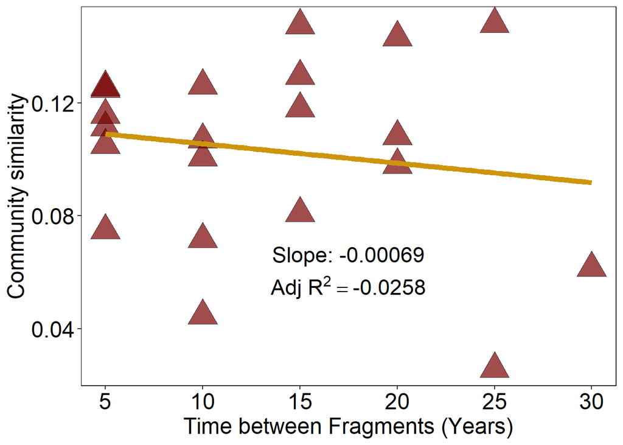

```r
#Plot the data
PNG_Diplo_decade_dist_decay <- PNG_Diplo_decade_dist_decay_data %>%
  #Select the data
  ggplot(aes(x = Core_distance, y = Community_sim)) +
  #Select the type of plot
  geom_point(shape = 24, size = 8, fill = "#780000", alpha = 0.7) +
  #Include the regresion line
  geom_smooth(method = "lm", se = F, linewidth = 2, color = "darkgoldenrod3") +
  #Include the adj p-value and Adj R-squares
    annotate(geom = "text", x = 17.5, y = 0.06, label = paste0("atop('Slope: ", signif(PNG_Diplo_decade_dist_decay_lm$coefficients["Core_distance"], 3), "', 'Adj R'^2=='", signif(PNG_Diplo_decade_dist_decay_lm_sum$adj.r.squared, 3), "')"), size = 6, parse = T) +
  #Change the labels
  labs(x = "Time between Fragments (Years)", y = "Community similarity") +
  #Include x axis breaks
  scale_x_continuous(breaks = c(0, 5, 10, 15, 20, 25, 30)) +
  #Modify y axis limits
  scale_y_continuous(breaks = c(0.04, 0.08, 0.12)) +
  #Change the theme
  theme(panel.grid = element_blank(),
        panel.background = element_rect(fill = "white",  color = "black"),
        axis.text = element_text(size = 18, color = "black"),
        axis.title = element_text(size = 18, color = "black"),
        legend.position = "bottom",
        legend.key = element_rect(fill = "white", color = "white"),
        legend.title = element_text(color = "black", size = 12),
        legend.text = element_text(color = "black", size = 12))

PNG_Diplo_decade_dist_decay
```

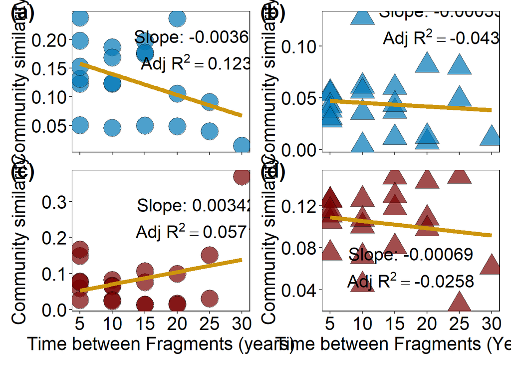

```r
Figure_S2 <- (Palau_Porites_decade_dist_decay | PNG_Porites_decade_dist_decay)/(Palau_Diplo_decade_dist_decay | PNG_Diplo_decade_dist_decay) +
  plot_layout(axes = "collect") + plot_annotation(tag_levels = "a", tag_prefix = "(", tag_suffix = ")") & theme(plot.tag = element_text(size = 20, face = "bold"), plot.tag.position = c(0.05, 1))

Figure_S2
```

```r
#ggsave(filename = "Figures/Figure_S2.svg", width = 370, height = 250, units = "mm", dpi = 1800)
#ggsave(filename = "Figures/Figure_S2.pdf", width = 370, height = 300, units = "mm", dpi = 1800)
#ggsave(filename = "Figures/Figure_S2.png", width = 370, height = 250, units = "mm", dpi = 1500)
```

## Aim 3: Dynamics related to past environmental changes

**Probe differences in the reconstruction dynamics between two massive growing coral species in the context of past potential heat stress events.**

In order to answer this data, we will start by processing the bleaching data taken from the NOAA Coral Reef Watch

https://coralreefwatch.noaa.gov/product/5km/index.php#data_access

Data download website (as csv): https://pae-paha.pacioos.hawaii.edu/erddap/griddap/dhw_5km.html

Once the data was downloaded as a csv file and joined into one dataframe we proceeded to clean up the data (Separate and filter the dates according to the sampling dates)

Core Metadata:

| Core ID | Location | Sampling date | Species | Dimensions (cm) | Linear extension rate (mm/year) |
| --- | --- | --- | --- | --- | --- |
| I23 S2 | PNG | 2017-11-06 | Porites | 1.8 - 2.0 | 9.9 |
| I23 S2 c18 | PNG | 2017-11-06 | Diplo | 0.7 - 0.8 | 4.1 |
| I26 S1 c26 | Palau | 2018-01-06 | Porites | 1.6 - 3.6 | 9.4 |
| I26 S1 c27 | Palau | 2018-01-06 | Diplo | 1.0 - 1.5 | 5.1 |

```r
#Create a Core calcification metadata file
Core_metadata <- data.frame(Location = c("PNG", "PNG", "Palau", "Palau"),
                            Sampling_date = c(as.Date("2017-11-06"), as.Date("2017-11-06"), as.Date("2018-01-06"), as.Date("2018-01-06")),
                            Coral_genus = c("Porites", "Diplo", "Porites", "Diplo"),
                            Dimension_right_cm = c(1.8, 0.7, 1.6, 1.0),
                            Dimension_left_cm = c(2.0, 0.8, 3.6, 1.5),
                            Linear_ext_rate_mm_year = c(9.9, 4.1, 9.4, 5.1)) %>%
  #Group the data
  group_by(Location, Sampling_date, Coral_genus, Linear_ext_rate_mm_year) %>%
  #Calculate the age of the head fragments
  summarize(Avg_dimension_cm = mean(Dimension_right_cm, Dimension_left_cm),

         Avg_dimension_mm = Avg_dimension_cm * 10,

         Fragment_age_years = (Avg_dimension_mm/Linear_ext_rate_mm_year))
```

```
## You can override using the `.groups` argument.
```

```r
Core_metadata
```

```
## # A tibble: 4 × 7
## # Groups:   Location, Sampling_date, Coral_genus [4]
##   Location Sampling_date Coral_genus Linear_ext_rate_mm_year Avg_dimension_cm
##   <chr>    <date>        <chr>                         <dbl>            <dbl>
## 1 PNG      2017-11-06    Diplo                           4.1              0.7
## 2 PNG      2017-11-06    Porites                         9.9              1.8
## 3 Palau    2018-01-06    Diplo                           5.1              1
## 4 Palau    2018-01-06    Porites                         9.4              1.6
## # ℹ 2 more variables: Avg_dimension_mm <dbl>, Fragment_age_years <dbl>
```

```r
#_________________________________________________________________________________________

#Data for Palau

NOAA_CRW_Palau <- NOAA_CRW %>%
  #Create new varaibles based on the time variable
  separate(col = "Time_UTC", into = c("Year", "Month", "Day_time"), sep = "-", remove = F) %>%
  #Modify the day variable
  separate(Day_time, into = c("Day", "Time"), sep = "T", remove = T) %>%
  #Modify the type of data
  mutate(across(c("Year", "Month", "Day", "Latitude_North", "Longitude_East", "Bleaching_alert_area", "Degree_heating_week_Celsius_Week", "Coral_bleaching_hotspot_Celsius", "SST_Celsius", "SST_Anomaly_Celsius"), .fns = as.numeric)) %>%
  #Separate date and time info
  separate(col = "Time_UTC", into = c("Date", "Time"), sep = "T", remove = T) %>%
  #Modify the variable type
  mutate(Date = ymd(Date, tz = "UTC")) %>%
  #Apply the filter
  filter(Location == "Palau" & Date <= "2018-01-06") %>%
  #Include  a variable that has the 5 - year intervals per sample
  mutate(Core_years = case_when(Date <= "2018-01-06" & Date > "2016-01-06" ~ "0",
                                Date <= "2016-01-06" & Date > "2011-01-06" ~ "5",
                                Date <= "2011-01-06" & Date > "2006-01-06" ~ "10",
                                Date <= "2006-01-06" & Date > "2001-01-06" ~ "15",
                                Date <= "2001-01-06" & Date > "1996-01-06" ~ "20",
                                Date <= "1996-01-06" & Date > "1991-01-06" ~ "25",
                                Date <= "1991-01-06" & Date > "1986-01-06" ~ "30"))
#___________________________________________________________________

#Data for PNG

NOAA_CRW_PNG <- NOAA_CRW %>%
  #Create new varaibles based on the time variable
  separate(col = "Time_UTC", into = c("Year", "Month", "Day_time"), sep = "-", remove = F) %>%
  #Modify the day variable
  separate(Day_time, into = c("Day", "Time"), sep = "T", remove = T) %>%
  #Modify the type of data
  mutate(across(c("Year", "Month", "Day", "Latitude_North", "Longitude_East", "Bleaching_alert_area", "Degree_heating_week_Celsius_Week", "Coral_bleaching_hotspot_Celsius", "SST_Celsius", "SST_Anomaly_Celsius"), .fns = as.numeric)) %>%
  #Separate date and time info
  separate(col = "Time_UTC", into = c("Date", "Time"), sep = "T", remove = T) %>%
  #Modify the variable type
  mutate(Date = ymd(Date, tz = "UTC")) %>%
  #Apply the filter
  filter(Location == "PNG" & Date < "2017-11-07")  %>%
  #Include  a variable that has the 5 - year intervals per sample
  mutate(Core_years = case_when(Date <= "2017-11-06" & Date > "2015-11-06" ~ "0",
                                Date <= "2015-11-06" & Date > "2010-11-06" ~ "5",
                                Date <= "2010-11-06" & Date > "2005-11-06" ~ "10",
                                Date <= "2005-11-06" & Date > "2000-11-06" ~ "15",
                                Date <= "2000-11-06" & Date > "1995-11-06" ~ "20",
                                Date <= "1995-11-06" & Date > "1990-11-06" ~ "25",
                                Date <= "1990-11-06" & Date > "1985-11-06" ~ "30"))
#___________________________________________________________________


NOAA_CRW_clean <- bind_rows(NOAA_CRW_Palau, NOAA_CRW_PNG) %>%
  #Rename the time period variable
  rename(Time_period = Time.period) %>%
  #Change the data format
  mutate(Date = as.Date(Date))
```

Now we will investigate the bleaching alerts

```r
#Total number of bleaching alerts per location
NOAA_CRW_clean %>%
  #Obtain bleaching alerts
  filter(Bleaching_alert_area > 0 & !is.na(Core_years)) %>%
  #Group the data
  group_by(Location, Bleaching_alert_area) %>%
  #Obtain the total number of bleaching alerts in the time series
  summarize(Total_Bleaching_alerts = n())
```

```
## # A tibble: 6 × 3
## # Groups:   Location [2]
##   Location Bleaching_alert_area Total_Bleaching_alerts
##   <chr>                   <dbl>                  <int>
## 1 PNG                         1                   3131
## 2 PNG                         2                    335
## 3 PNG                         3                     69
## 4 Palau                       1                   3760
## 5 Palau                       2                    168
## 6 Palau                       3                     56
```

```r
#Number of bleaching alerts per location and Core_year
NOAA_CRW_clean %>%
  #Obtain bleaching alerts
  filter(Bleaching_alert_area > 0 & !is.na(Core_years)) %>%
  #Group the data
  group_by(Location, Core_years, Bleaching_alert_area) %>%
  #Obtain the total number of bleaching in the time series
  summarize(Total_Bleaching_alerts = n()) %>%
  #Ungroup the data
  ungroup() %>%
  #Create a new variable for normalization
  mutate(Bleaching_alert_year_interval = case_when(Core_years == "0" ~ Total_Bleaching_alerts/2,
                                                   TRUE ~ Total_Bleaching_alerts/5))
```

```
## # A tibble: 36 × 5
##    Location Core_years Bleaching_alert_area Total_Bleaching_alerts
##    <chr>    <chr>                     <dbl>                  <int>
##  1 PNG      0                             1                    281
##  2 PNG      0                             2                     46
##  3 PNG      0                             3                     30
##  4 PNG      10                            1                    689
##  5 PNG      10                            2                     57
##  6 PNG      10                            3                     20
##  7 PNG      15                            1                    487
##  8 PNG      15                            2                     47
##  9 PNG      15                            3                     11
## 10 PNG      20                            1                    512
## # ℹ 26 more rows
## # ℹ 1 more variable: Bleaching_alert_year_interval <dbl>
```

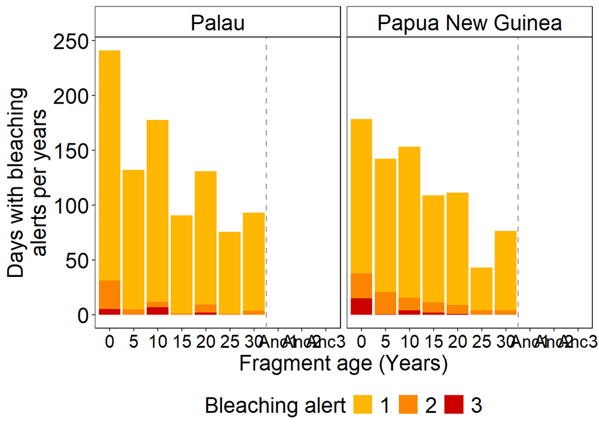

```r
#_______________________________________________________________________

#Number of bleaching alerts per location and Core_year

##Joined plot

Bleaching_alert_joined <- NOAA_CRW_clean %>%
  #Obtain bleaching alerts
  filter(Bleaching_alert_area > 0 & !is.na(Core_years)) %>%
  #Group the data
  group_by(Location, Core_years, Bleaching_alert_area) %>%
  #Obtain the total number of bleaching in the time series
  summarize(Total_Bleaching_alerts = n()) %>%
  #Ungroup the data
  ungroup() %>%
  #Include a new variable for the plot
  mutate(Core_years = factor(x = Core_years, levels = c("0", "5", "10", "15", "20", "25", "30")#, labels = c("2018\n(0)", "2018 9- 2013\n(5)", "2013 - 2008\n(10)", "2008 - 2003\n(15)", "2003 - 1998\n(20)", "1998 - 1993\n(25", "1993 - 1988\n(30)")
                             ),

         Bleaching_alert_area = factor(x = Bleaching_alert_area, levels = c("1", "2", "3")),

         Location_2 = case_when(Location == "PNG" ~ "Papua New Guinea",
                                TRUE ~ Location)) %>%
  #Create a new variable for normalization
  mutate(Bleaching_alert_year_interval = case_when(Core_years == "0" ~ Total_Bleaching_alerts/2,
                                                   TRUE ~ Total_Bleaching_alerts/5)) %>%
  #Select the data for plotting
  ggplot(aes(x = Core_years, y = Bleaching_alert_year_interval, fill = Bleaching_alert_area)) +
  #Select the type of plot
  geom_col() +
  #Change the colors
  scale_fill_manual(values = c("#ffb703", "#fb8500", "red3"), name = "Bleaching alert") +
  #Change the x axis breacks
  scale_x_discrete(limits = c("0", "5", "10", "15", "20", "25", "30", "Anc1", "Anc2", "Anc3")) +
  #Include a vertical line to indicate the ancient samples
  geom_vline(xintercept = 7.5, linetype = "dashed", linewidth = 0.7, color = "darkgray") +
  #Include facets
  facet_grid(cols = vars(Location_2)) +
  #Change the axes labels
    labs(x = "Fragment age (Years)", y = "Days with bleaching\nalerts per years") +
  #Modify the theme
  theme(
    #Eliminate panel grids
    panel.grid = element_blank(),
    #Change background color
    panel.background = element_rect(fill = "white", color = "black"),
    #Increase axes label text size
    #axis.text = element_text(color = "black", size = 16), #Original size = 12
    axis.title = element_text(color = "black", size = 18), #Original size = 12
    #Change the color of the facet label
    strip.background = element_rect(fill = "white", color = "black"),
    #Increase facet label text size
    strip.text = element_text(color = "black", size = 18), #Original size = 12
    #Change the legend
    axis.text.y = element_text(color = "black", size = 18), #Original size = 12
    axis.text.x = element_text(color = "black", size = 15), #Original size = 9
    legend.title = element_text(color = "black", size = 18), #Original size = 12
    legend.key = element_rect(color = "white"),
    legend.text = element_text(color = "black", size = 18), #Original size = 12
    legend.position = "bottom"
    )
Bleaching_alert_joined
```

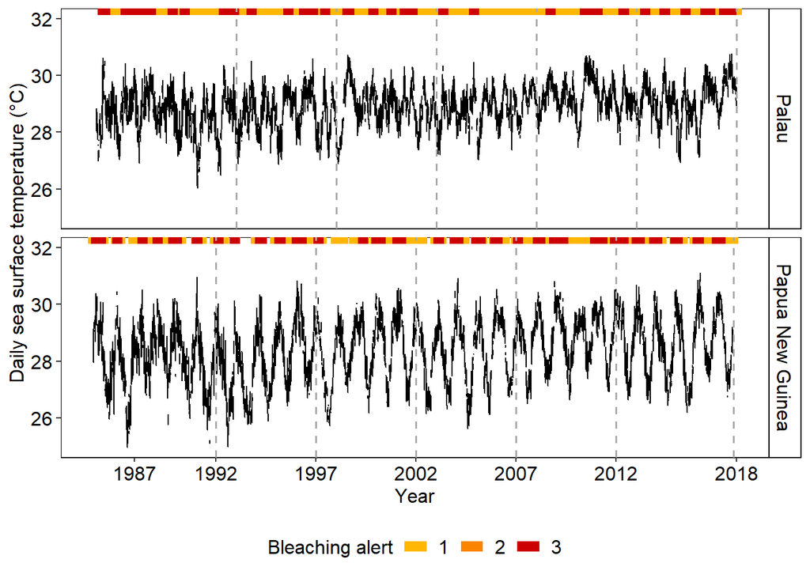

```r
Fig_S4 <- NOAA_CRW_clean %>%
  #Create a new variable for the plot
  mutate(Location_plot = case_when(Location == "PNG" ~ "Papua New Guinea",
                                   TRUE ~ Location)) %>%
  #Filter out the non-used data
  filter(!is.na(Core_years)) %>%
  #Select the data
  ggplot(aes(x = Date, y = SST_Celsius)) +
  #Select the type of plot
  geom_line() +
  #Include bleaching alert
  geom_rug(aes(x = Date, y = 32, color = Bleaching_alert_area), data = NOAA_CRW_clean %>% filter(Bleaching_alert_area > 0 & !is.na(Core_years)) %>% mutate(Bleaching_alert_area = factor(x = Bleaching_alert_area, levels = c("1", "2", "3"))), size = 3, show.legend = T, sides = "t") +
  #Assign the colors
  scale_color_manual(values = c("#ffb703", "#fb8500", "red3"), name = "Bleaching alert") +
  #Include to improve visualization
  geom_rug(aes(x = Date, y = 31, color = Bleaching_alert_area), color = "#ffb703", data = NOAA_CRW_clean %>% filter(Bleaching_alert_area == 1 & !is.na(Core_years)), sides = "t") +
  #Include to improve visualization
  geom_rug(aes(x = Date, y = 31, color = Bleaching_alert_area), color = "#fb8500", data = NOAA_CRW_clean %>% filter(Bleaching_alert_area == 2 & !is.na(Core_years)), size = 3, sides = "t") +
  #Include to improve visualization
  geom_rug(aes(x = Date, y = 31, color = Bleaching_alert_area), color = "red3", data = NOAA_CRW_clean %>% filter(Bleaching_alert_area == 2 & !is.na(Core_years)), size = 3, sides = "t") +
  #Include vertical lines indicating the period of each sample
  ##Palau
  geom_vline(aes(xintercept = as.Date("2018-01-01")), linetype = "dashed", linewidth = 0.7, color = "darkgray", data = NOAA_CRW_clean %>% mutate(Date = as.Date(Date)) %>% filter(Location == "Palau")) +
  geom_vline(aes(xintercept = as.Date("2013-01-01")), linetype = "dashed", linewidth = 0.7, color = "darkgray", data = NOAA_CRW_clean %>% mutate(Date = as.Date(Date)) %>% filter(Location == "Palau")) +
  geom_vline(aes(xintercept = as.Date("2008-01-01")), linetype = "dashed", linewidth = 0.7, color = "darkgray", data = NOAA_CRW_clean %>% mutate(Date = as.Date(Date)) %>% filter(Location == "Palau")) +
  geom_vline(aes(xintercept = as.Date("2003-01-01")), linetype = "dashed", linewidth = 0.7, color = "darkgray", data = NOAA_CRW_clean %>% mutate(Date = as.Date(Date)) %>% filter(Location == "Palau")) +
  geom_vline(aes(xintercept = as.Date("1998-01-01")), linetype = "dashed", linewidth = 0.7, color = "darkgray", data = NOAA_CRW_clean %>% mutate(Date = as.Date(Date)) %>% filter(Location == "Palau")) +
  geom_vline(aes(xintercept = as.Date("1993-01-01")), linetype = "dashed", linewidth = 0.7, color = "darkgray", data = NOAA_CRW_clean %>% mutate(Date = as.Date(Date)) %>% filter(Location == "Palau")) +
  ##PNG
  geom_vline(aes(xintercept = as.Date("2017-11-06")), linetype = "dashed", linewidth = 0.7, color = "darkgray", data = NOAA_CRW_clean %>% mutate(Date = as.Date(Date)) %>% filter(Location == "PNG")) +
  geom_vline(aes(xintercept = as.Date("2012-01-01")), linetype = "dashed", linewidth = 0.7, color = "darkgray", data = NOAA_CRW_clean %>% mutate(Date = as.Date(Date)) %>% filter(Location == "PNG")) +
  geom_vline(aes(xintercept = as.Date("2007-01-01")), linetype = "dashed", linewidth = 0.7, color = "darkgray", data = NOAA_CRW_clean %>% mutate(Date = as.Date(Date)) %>% filter(Location == "PNG")) +
  geom_vline(aes(xintercept = as.Date("2002-01-01")), linetype = "dashed", linewidth = 0.7, color = "darkgray", data = NOAA_CRW_clean %>% mutate(Date = as.Date(Date)) %>% filter(Location == "PNG")) +
  geom_vline(aes(xintercept = as.Date("1997-01-01")), linetype = "dashed", linewidth = 0.7, color = "darkgray", data = NOAA_CRW_clean %>% mutate(Date = as.Date(Date)) %>% filter(Location == "PNG")) +
  geom_vline(aes(xintercept = as.Date("1992-01-01")), linetype = "dashed", linewidth = 0.7, color = "darkgray", data = NOAA_CRW_clean %>% mutate(Date = as.Date(Date)) %>% filter(Location == "PNG")) +
  #Control the axis breaks
  scale_x_date(breaks = c(as.Date("1987-12-01"), as.Date("1992-01-01"), as.Date("1997-01-01"), as.Date("2002-01-01"), as.Date("2007-01-01"), as.Date("2012-01-01"), as.Date("2018-01-01")), date_labels = "%Y" ) +
  #Include facets by locations
  facet_grid(rows = vars(Location), labeller = labeller(Location = c("PNG" = "Papua New Guinea", "Palau" = "Palau"))) +
  #Modify axes labels
  labs(y = "Daily sea surface temperature (°C)", x = "Year") +
  #Modify the theme
  theme(
    #Eliminate panel grids
    panel.grid = element_blank(),
    #Change background color
    panel.background = element_rect(fill = "white", color = "black"),
    #Increase axes label text size
    axis.text = element_text(color = "black", size = 12),
    axis.title = element_text(color = "black", size = 12),
    #Change the color of the facet label
    strip.background = element_rect(fill = "white", color = "black"),
    #Increase facet label text size
    strip.text = element_text(color = "black", size = 12),
    #Change the legend
    legend.text = element_text(color = "black", size = 12),
    legend.title = element_text(color = "black", size = 12),
    legend.position = "bottom",
    legend.key = element_rect(color = "white")
    )


Fig_S4
```

```r
#ggsave(filename = "SST_timeline.png", width = 180, height = 150, units = "mm", dpi = 1800)
```

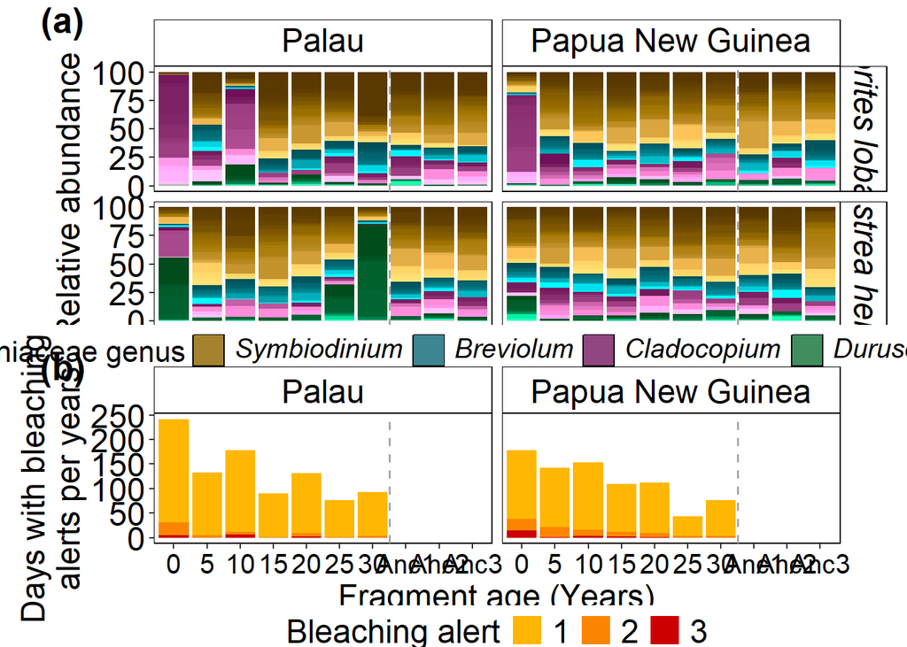

```r
#Create the layout
Location_species_bar_bleaching_alert_layout <- "
A
B
C
D"

#Extract the legend of the Symbiont bar plot
Location_species_bar_plot_legend <- ggpubr::as_ggplot(ggpubr::get_legend(Location_species_bar_plot))
#Extract the legend of the bleaching alert plot
Bleaching_alert_joined_legend <- ggpubr::as_ggplot(ggpubr::get_legend(Bleaching_alert_joined))

#Join the plots
Figure_4 <- Location_species_bar_plot + Location_species_bar_plot_legend + Bleaching_alert_joined + Bleaching_alert_joined_legend +
  #Include the layout
  plot_layout(heights = c(2, 0.1, 1, 0.1), design = Location_species_bar_bleaching_alert_layout) +
  #Include the tags
  plot_annotation(tag_levels = list(c("(a)", "", "(b)", ""))) & theme(plot.tag = element_text(size = 20, face = "bold"), legend.position = "none", plot.tag.position = c(0.05, 1) )

Figure_4
```

```r
#ggsave(filename = "Figures/Figure_4.svg", width = 300, height = 300, units = "mm", dpi = 1800)
#ggsave(filename = "Figures/Figure_4.pdf", width = 300, height = 300, units = "mm", dpi = 1800)
#ggsave(filename = "Figures/Figure_4.png", width = 300, height = 300, units = "mm", dpi = 1800)
```